# Taller Parcial 3

Sebastian Tabares Segovia

2026-06-30

```r
knitr::opts_chunk$set(
  echo       = TRUE,
  warning    = FALSE,
  message    = FALSE,
  cache = FALSE,
  fig.width  = 8,
  fig.height = 5,
  dpi        = 300,
  fig.align  = "center"
)
```

# 1. Introducción

La minería de datos constituye una de las principales herramientas para extraer conocimiento a partir de grandes volúmenes de información, permitiendo identificar patrones, construir modelos predictivos y apoyar la toma de decisiones en diferentes áreas del conocimiento. En el sector salud, estas metodologías adquieren una especial relevancia debido a la creciente disponibilidad de registros clínicos y administrativos generados durante la atención de los pacientes.

Sin embargo, trabajar con bases de datos reales implica afrontar desafíos que rara vez están presentes en conjuntos de datos diseñados con fines educativos. Es frecuente encontrar registros incompletos, inconsistencias entre diferentes observaciones de un mismo paciente, valores atípicos en los costos, categorías mal codificadas y enfermedades cuya frecuencia dentro de la población es relativamente baja. Por ello, una parte fundamental del proceso consiste en la limpieza, transformación y preparación de los datos antes de iniciar cualquier etapa de modelamiento.

En este trabajo se utilizará una base de datos real correspondiente a la utilización de servicios de salud suplementaria en Brasil, compuesta por más de nueve millones de registros asociados a aproximadamente **653.000 beneficiarios únicos**. Cada registro representa una utilización de servicios médicos y contiene información relacionada con diagnósticos, procedimientos realizados, hospitalizaciones, utilización de unidades de cuidado intensivo, características demográficas del beneficiario y costos asociados a la atención.

La enfermedad seleccionada para este estudio corresponde al **Trastorno del Espectro Autista (TEA)**, identificado mediante los códigos **F84.x** de la **Clasificación Internacional de Enfermedades (CIE-10)**. Esta condición fue elegida debido a que presenta un patrón particular de utilización de los servicios de salud, caracterizado por una alta frecuencia de consultas especializadas, terapias de rehabilitación y seguimiento multidisciplinario, lo que la convierte en un caso de estudio adecuado para la construcción de modelos predictivos y el análisis de costos asociados.

Finalmente, el objetivo del presente trabajo es desarrollar un proceso completo de minería de datos que incluya la preparación de la información, la construcción de la variable objetivo, el análisis descriptivo de la población, el entrenamiento y comparación de diferentes modelos de clasificación, la interpretación de los resultados obtenidos y la estimación del costo esperado asociado a la enfermedad seleccionada.

# 2. Metodología

El desarrollo del presente trabajo seguirá las principales etapas del proceso **KDD (Knowledge Discovery in Databases)**, metodología ampliamente utilizada en minería de datos para transformar grandes volúmenes de información en conocimiento útil.

Las etapas desarrolladas serán:

1. **Comprensión del problema**, mediante la selección de la enfermedad de estudio y la definición de la variable objetivo.
2. **Selección y preparación de los datos**, incluyendo la identificación de inconsistencias, tratamiento de valores faltantes, construcción de variables y agregación de la información a nivel de beneficiario.
3. **Análisis exploratorio**, con el fin de caracterizar la población estudiada e identificar patrones relevantes.
4. **Modelamiento predictivo**, entrenando y comparando diferentes algoritmos de clasificación.
5. **Evaluación e interpretación**, utilizando métricas de desempeño e importancia de variables para comprender el comportamiento de los modelos.
6. **Generación de conocimiento**, mediante la estimación del costo esperado asociado al Trastorno del Espectro Autista y la discusión de los principales hallazgos del estudio.

En la práctica, estas seis etapas conceptuales se materializan en **11 secciones principales** dentro del documento (numeradas de la 3 a la 11, ya que la 1 y la 2 corresponden a esta introducción y metodología), pues varias etapas del KDD —en particular la preparación de datos y el modelamiento— requirieron subdividirse para separar la carga y limpieza inicial, la construcción de la base analítica, el modelamiento supervisado y no supervisado, la comparación de modelos y la estimación de costos como bloques independientes. El árbol completo de secciones y subsecciones, con su numeración, se documenta en el `README.txt` del repositorio.

```r
library(data.table)
library(tidyverse)
library(lubridate)
library(caret)
library(ggplot2)
```

# 3. Comprensión y carga inicial de los datos

La base original contiene registros de utilización de servicios de salud. Cada fila puede representar un procedimiento asociado a una atención médica, por lo que un mismo beneficiario puede aparecer múltiples veces y una misma utilización puede contener varios procedimientos.

```r
ruta_datos <- "C:/Users/sebas/OneDrive - Universidad de los Andes/Estadística/3_Semestre/Mineria_de_datos/Talleres_Parciales/taller_parcial_3/db_2026.csv"
```

```r
# Leer la base completa

datos <- fread(
  ruta_datos,
  encoding = "UTF-8"
)
```

Con el fin de conocer el volumen de información disponible, se calcula el número de registros y variables presentes en la base de datos.

```r
# Número de filas y columnas

dim(datos)
```

```
## [1] 9345278      16
```

**Interpretación**

La base de datos contiene **9.345.278 registros** y **16 variables**. Cada registro corresponde a una utilización de servicios de salud, por lo que un mismo beneficiario puede aparecer múltiples veces a lo largo del período de estudio.

El elevado volumen de información justifica el uso del paquete `data.table`, el cual permite manipular grandes conjuntos de datos de forma eficiente.

**Conclusión**

Antes de iniciar el modelamiento será necesario transformar esta base transaccional en una base analítica, agregando la información a nivel de beneficiario mediante la variable `CHAVE_FUNCIONAL`.

## 3.1 Variables disponibles

La siguiente tabla presenta las variables incluidas en la base de datos que serán utilizadas durante las diferentes etapas del análisis.

```r
# Tabla con las variables disponibles

variables <- tibble(
  Variable = names(datos)
)

knitr::kable(
  variables,
  caption = "Variables disponibles en la base de datos"
)
```

Variables disponibles en la base de datos

| Variable |
| --- |
| CID |
| UTI |
| INTERNADO |
| PORTE_ANESTESICO |
| DT_UTILIZACAO |
| DESC_ESPECIALIDADE |
| TIPO_UNIDADE_PREST_HOSPITALAR |
| UF_CNES_PREST_HOSPITALAR |
| DT_NASCIMENTO_BENEFICIARIO |
| TIPO_BENEFICIARIO |
| SEXO_BENEFICIARIO |
| CETIPO |
| CD_PROCEDIMENTO |
| DESCRICAO_PROCEDIMENTO |
| VALOR_UTILIZACAO |
| CHAVE_FUNCIONAL |

**Interpretación**

Las 16 variables disponibles incluyen información clínica, demográfica, administrativa y económica. Destacan especialmente el código diagnóstico (`CID`), el identificador único del beneficiario (`CHAVE_FUNCIONAL`) y el valor económico asociado a cada utilización (`VALOR_UTILIZACAO`), variables que serán fundamentales durante la construcción del conjunto de datos para el modelamiento.

```r
# Estructura de la base

glimpse(datos)
```

```
## Rows: 9,345,278
## Columns: 16
## $ CID                           <chr> "N/A", "N/A", "N/A", "N/A", "N/A", "N/A"…
## $ UTI                           <int> 0, 0, 0, 0, 0, 0, 0, 0, 0, 0, 0, 0, 0, 0…
## $ INTERNADO                     <int> 0, 0, 0, 0, 0, 0, 0, 0, 0, 0, 0, 0, 0, 0…
## $ PORTE_ANESTESICO              <int> 0, 0, NA, 0, 0, 0, 0, 0, 0, 0, 0, 0, 0, …
## $ DT_UTILIZACAO                 <IDate> 2026-01-17, 2026-01-21, 2026-01-19, 20…
## $ DESC_ESPECIALIDADE            <chr> "-", "-", "-", "-", "-", "-", "-", "-", …
## $ TIPO_UNIDADE_PREST_HOSPITALAR <chr> "-", "-", "-", "-", "-", "-", "-", "-", …
## $ UF_CNES_PREST_HOSPITALAR      <chr> "-", "-", "-", "-", "-", "-", "-", "-", …
## $ DT_NASCIMENTO_BENEFICIARIO    <IDate> 1993-11-11, 2002-05-29, 1986-04-29, 20…
## $ TIPO_BENEFICIARIO             <chr> "TITULAR", "TITULAR", "TITULAR", "DEPEND…
## $ SEXO_BENEFICIARIO             <chr> "F", "F", "F", "M", "F", "M", "F", "M", …
## $ CETIPO                        <chr> "Exame", "Exame", "Outros", "Consulta", …
## $ CD_PROCEDIMENTO               <int> 41401271, 41401271, 90101040, 10101012, …
## $ DESCRICAO_PROCEDIMENTO        <chr> "Teste de sensibilidade de contraste ou …
## $ VALOR_UTILIZACAO              <dbl> 23.82, 23.82, 140.34, 131.50, 117.01, 10…
## $ CHAVE_FUNCIONAL               <chr> "0e1d2227-9f44-4856-89b7-b148ed7d490e", …
```

**Interpretación**

La inspección de la estructura muestra que las fechas fueron correctamente reconocidas como variables de tipo `Date`, mientras que los costos fueron importados como variables numéricas (`double`). Asimismo, las variables categóricas, como el diagnóstico (`CID`), el sexo y la especialidad médica, fueron almacenadas como caracteres.

Se observa además la presencia de valores faltantes en variables como `PORTE_ANESTESICO` y `DT_NASCIMENTO_BENEFICIARIO`, aspecto que deberá analizarse durante la etapa de limpieza de los datos.

```r
# Primeras observaciones

knitr::kable(
  head(datos),
  caption = "Primeros registros de la base de datos"
)
```

Primeros registros de la base de datos

| CID | UTI | INTERNADO | PORTE_ANESTESICO | DT_UTILIZACAO | DESC_ESPECIALIDADE | TIPO_UNIDADE_PREST_HOSPITALAR | UF_CNES_PREST_HOSPITALAR | DT_NASCIMENTO_BENEFICIARIO | TIPO_BENEFICIARIO | SEXO_BENEFICIARIO | CETIPO | CD_PROCEDIMENTO | DESCRICAO_PROCEDIMENTO | VALOR_UTILIZACAO | CHAVE_FUNCIONAL |
| --- | --- | --- | --- | --- | --- | --- | --- | --- | --- | --- | --- | --- | --- | --- | --- |
| N/A | 0 | 0 | 0 | 2026-01-17 | - | - | - | 1993-11-11 | TITULAR | F | Exame | 41401271 | Teste de sensibilidade de contraste ou de cores - monocular | 23.82 | 0e1d2227-9f44-4856-89b7-b148ed7d490e |
| N/A | 0 | 0 | 0 | 2026-01-21 | - | - | - | 2002-05-29 | TITULAR | F | Exame | 41401271 | Teste de sensibilidade de contraste ou de cores - monocular | 23.82 | 8ca0baa2-427b-4c31-8c27-48891539edfc |
| N/A | 0 | 0 | NA | 2026-01-19 | - | - | - | 1986-04-29 | TITULAR | F | Outros | 90101040 | Outros registros não mapeados sem DePara | 140.34 | 30c0bc73-4422-4717-83dd-a33794cbd7c2 |
| N/A | 0 | 0 | 0 | 2026-01-13 | - | - | - | 2022-01-19 | DEPENDENTE | M | Consulta | 10101012 | Em consultório (no horário normal ou preestabelecido) | 131.50 | cdf73a8c-7e26-4f76-936b-f7671938dc3d |
| N/A | 0 | 0 | 0 | 2026-01-14 | - | - | - | 1982-01-15 | TITULAR | F | Consulta | 10101012 | Em consultório (no horário normal ou preestabelecido) | 117.01 | 2f930773-b64a-4aaa-97a1-222c1ede5db7 |
| N/A | 0 | 0 | 0 | 2026-01-12 | - | - | - | 1986-01-09 | TITULAR | M | Consulta | 10101012 | Em consultório (no horário normal ou preestabelecido) | 107.83 | d40078a5-d15b-408b-899c-de5a82021775 |

```r
# Resumen descriptivo

summary(datos)
```

```
##      CID                 UTI             INTERNADO       PORTE_ANESTESICO
##  Length:9345278     Min.   :0.000000   Min.   :0.00000   Min.   :0.0
##  Class :character   1st Qu.:0.000000   1st Qu.:0.00000   1st Qu.:0.0
##  Mode  :character   Median :0.000000   Median :0.00000   Median :0.0
##                     Mean   :0.003006   Mean   :0.01622   Mean   :0.1
##                     3rd Qu.:0.000000   3rd Qu.:0.00000   3rd Qu.:0.0
##                     Max.   :1.000000   Max.   :1.00000   Max.   :8.0
##                                                          NA's   :4202557
##  DT_UTILIZACAO        DESC_ESPECIALIDADE TIPO_UNIDADE_PREST_HOSPITALAR
##  Min.   :2026-01-01   Length:9345278     Length:9345278
##  1st Qu.:2026-01-15   Class :character   Class :character
##  Median :2026-01-29   Mode  :character   Mode  :character
##  Mean   :2026-02-05
##  3rd Qu.:2026-02-24
##  Max.   :2026-12-08
##
##  UF_CNES_PREST_HOSPITALAR DT_NASCIMENTO_BENEFICIARIO TIPO_BENEFICIARIO
##  Length:9345278           Min.   :1900-01-01         Length:9345278
##  Class :character         1st Qu.:1962-05-02         Class :character
##  Mode  :character         Median :1981-05-17         Mode  :character
##                           Mean   :1980-08-17
##                           3rd Qu.:1996-08-04
##                           Max.   :2049-12-30
##                           NA's   :1940
##  SEXO_BENEFICIARIO     CETIPO          CD_PROCEDIMENTO
##  Length:9345278     Length:9345278     Min.   :10101012
##  Class :character   Class :character   1st Qu.:40301630
##  Mode  :character   Mode  :character   Median :40316491
##                                        Mean   :50982768
##                                        3rd Qu.:90101040
##                                        Max.   :90101050
##
##  DESCRICAO_PROCEDIMENTO VALOR_UTILIZACAO    CHAVE_FUNCIONAL
##  Length:9345278         Min.   :-27537.23   Length:9345278
##  Class :character       1st Qu.:     4.56   Class :character
##  Mode  :character       Median :    17.39   Mode  :character
##                         Mean   :   106.85
##                         3rd Qu.:    73.75
##                         Max.   :628388.67
##
```

**Interpretación**

El resumen descriptivo evidencia que la mayoría de las utilizaciones no corresponden a hospitalizaciones (`INTERNADO`) ni ingresos a unidades de cuidados intensivos (`UTI`), lo cual resulta consistente con la utilización habitual de los servicios de salud.

Asimismo, se identificó una cantidad considerable de valores faltantes en la variable `PORTE_ANESTESICO`, mientras que la fecha de nacimiento presenta un número reducido de registros ausentes.

También se observa que existen fechas de nacimiento registradas hasta el año **2049**, lo que sugiere la presencia de posibles inconsistencias que deberán revisarse durante la etapa de depuración.

## 3.2 Verificación de los códigos asociados al TEA

Para identificar los registros relacionados con el Trastorno del Espectro Autista se seleccionaron los diagnósticos cuyo código CID comienza por `F84`. Esta estrategia permite incluir tanto la categoría general como sus posibles subcategorías.

Antes de construir la variable objetivo, se revisó la frecuencia de cada código encontrado para confirmar su presencia y detectar posibles inconsistencias en su escritura.

```r
codigos_tea <- datos %>%
  filter(str_detect(CID,"^F84")) %>%
  count(CID, sort = TRUE)

knitr::kable(
  codigos_tea,
  col.names = c("Código CID","Frecuencia"),
  caption = "Diagnósticos asociados al Trastorno del Espectro Autista"
)
```

Diagnósticos asociados al Trastorno del Espectro Autista

| Código CID | Frecuencia |
| --- | --- |
| F84 | 459 |
| F84.0 | 231 |
| F84.9 | 204 |
| F840 | 73 |
| F84. | 55 |
| F841 | 1 |
| F845 | 1 |

**Interpretación**

Se identificaron diferentes formas de registrar los diagnósticos asociados al Trastorno del Espectro Autista. Además de los códigos estandarizados de la CIE-10 (`F84.0` y `F84.9`), también aparecen registros sin punto decimal (`F840`, `F841`, `F845`) e incluso diagnósticos incompletos (`F84` y `F84.`).

Estas inconsistencias son habituales en bases de datos administrativas y evidencian la necesidad de estandarizar previamente los códigos diagnósticos antes de construir la variable objetivo.

```r
#Valores faltantes
colSums(is.na(datos))
```

```
##                           CID                           UTI
##                             0                             0
##                     INTERNADO              PORTE_ANESTESICO
##                             0                       4202557
##                 DT_UTILIZACAO            DESC_ESPECIALIDADE
##                             0                             0
## TIPO_UNIDADE_PREST_HOSPITALAR      UF_CNES_PREST_HOSPITALAR
##                             0                             0
##    DT_NASCIMENTO_BENEFICIARIO             TIPO_BENEFICIARIO
##                          1940                             0
##             SEXO_BENEFICIARIO                        CETIPO
##                             0                             0
##               CD_PROCEDIMENTO        DESCRICAO_PROCEDIMENTO
##                             0                             0
##              VALOR_UTILIZACAO               CHAVE_FUNCIONAL
##                             0                             0
```

**Interpretación**

La mayoría de las variables no presentan valores faltantes. Sin embargo, la variable `PORTE_ANESTESICO` registra aproximadamente **4,2 millones** de observaciones ausentes, mientras que `DT_NASCIMENTO_BENEFICIARIO` presenta **1.940** valores faltantes.

Dado que la ausencia de información se concentra en pocas variables, el tratamiento podrá realizarse de manera específica según la naturaleza de cada una.

# 4. Limpieza y preparación de los datos

Estandarización de los códigos diagnósticos (CID)

Antes de construir la variable objetivo es necesario estandarizar los códigos diagnósticos. Durante la inspección inicial se observó que un mismo diagnóstico puede encontrarse registrado de diferentes maneras, por ejemplo F84.0, F840, F84. o F84. Estas diferencias corresponden al mismo grupo diagnóstico, pero impedirían identificar correctamente todos los casos si no se realiza una limpieza previa.

**Paso 1. Visualizar algunos códigos diferentes**

```r
datos %>%
  distinct(CID) %>%
  arrange(CID) %>%
  head(30) %>%
  knitr::kable(
    caption = "Primeros códigos diagnósticos encontrados en la base"
  )
```

Primeros códigos diagnósticos encontrados en la base

[output not shown]

**Paso 2. Crear una copia del código original**

```r
datos <- datos %>%
  mutate(CID_original = CID)
```

**Paso 3. Estandarizar los códigos**

```r
datos <- datos %>%
  mutate(
    CID = str_to_upper(CID),
    CID = str_replace_all(CID, "\\s+", ""),
    CID = str_replace(CID, "^([A-Z][0-9]{2})([0-9])$", "\\1.\\2"),
    CID = str_remove(CID, "\\.$")
  )
```

**Paso 4. Verificar nuevamente los códigos TEA**

```r
codigos_tea <- datos %>%
  filter(str_detect(CID, "^F84")) %>%
  count(CID, sort = TRUE)

knitr::kable(
  codigos_tea,
  caption = "Códigos asociados al TEA después de la estandarización"
)
```

Códigos asociados al TEA después de la estandarización

| CID | n |
| --- | --- |
| F84.0 | 6819 |
| F84 | 3722 |
| F84.9 | 283 |
| F84.1 | 51 |
| F84.8 | 31 |
| F84.3 | 12 |
| F84.5 | 1 |

**Interpretación**

Después del proceso de estandarización se redujo la presencia de diferentes representaciones para un mismo diagnóstico. Esto permite identificar de forma consistente todos los registros pertenecientes al grupo F84 y facilita la construcción de la variable objetivo utilizada en los modelos predictivos.

## 4.1 Construcción de la variable objetivo

La variable objetivo del estudio corresponde a la presencia de **Trastorno del Espectro Autista (TEA)** en cada beneficiario. Para ello, se consideró como caso positivo a todo beneficiario que presentara al menos un diagnóstico perteneciente al grupo **F84** de la CIE-10, independientemente del número de atenciones registradas.

**Paso 1. Crear un indicador de TEA en cada registro**

```r
datos <- datos %>%
  mutate(
    TEA = if_else(str_detect(CID, "^F84"), 1, 0)
  )
```

**Paso 2. Verificar la distribución inicial**

```r
tabla_tea_registros <- datos %>%
  count(TEA)

knitr::kable(
  tabla_tea_registros,
  caption = "Distribución del indicador TEA a nivel de registros",
  format.args = list(big.mark = ".")
)
```

Distribución del indicador TEA a nivel de registros

| TEA | n |
| --- | --- |
| 0 | 9.334.359 |
| 1 | 10.919 |

**Interpretación**

La variable TEA fue construida asignando el valor 1 a todos los registros cuyo código diagnóstico pertenece al grupo F84 y 0 al resto de las observaciones. En esta etapa la clasificación aún corresponde al nivel de utilización, por lo que un mismo beneficiario puede aparecer varias veces.

**Paso 3. Construir la variable objetivo a nivel de beneficiario**

```r
beneficiarios <- datos %>%
  group_by(CHAVE_FUNCIONAL) %>%
  summarise(
    TEA = max(TEA),
    .groups = "drop"
  )
```

**Paso 4. Verificar la distribución final**

```r
tabla_beneficiarios <- beneficiarios %>%
  count(TEA)

knitr::kable(
  tabla_beneficiarios,
  caption = "Distribución del TEA a nivel de beneficiarios",
  format.args = list(big.mark = ".")
)
```

Distribución del TEA a nivel de beneficiarios

| TEA | n |
| --- | --- |
| 0 | 652.820 |
| 1 | 811 |

**Interpretación**

## 4.2 Construcción de la base analítica

Hasta este punto, la información se encuentra organizada a nivel de utilización de servicios de salud, por lo que un mismo beneficiario puede aparecer múltiples veces dentro de la base de datos.

Sin embargo, el objetivo del presente trabajo consiste en predecir si un beneficiario presenta o no un diagnóstico asociado al Trastorno del Espectro Autista (TEA). Por esta razón, resulta necesario construir una **base analítica**, donde cada fila represente un único beneficiario y las variables describan sus características demográficas, clínicas y de utilización de los servicios de salud.

Para ello, se agrupará la información utilizando la variable `CHAVE_FUNCIONAL`, generando variables resumen que posteriormente serán empleadas en el entrenamiento de los modelos predictivos.

### 4.2.1 Revisión de la consistencia de los datos

```r
table(datos$INTERNADO, useNA = "ifany")
```

```
##
##       0       1
## 9193734  151544
```

```r
table(datos$UTI, useNA = "ifany")
```

```
##
##       0       1
## 9317190   28088
```

```r
table(datos$SEXO_BENEFICIARIO, useNA = "ifany")
```

```
##
##             F             M     MASCULINO Não Informado
##       5260371       3477872             1        607034
```

```r
table(datos$TIPO_BENEFICIARIO, useNA = "ifany")
```

```
##
##      AGREGADO       CONJUGE    DEPENDENTE         FILHO      IGNORADO
##         71341         13994       3440704          8879          5934
##           MAE Não Informado        OUTROS       TITULAR      TUTELADO
##            63        611414         30820       5162127             2
```

Vemos que tanto **UTI** como **INTERNADO** tienen datos correctos. Sin embargo, podemos observar que **SEXO_BENEFICIARIO** tiene “Masculino” registrado de dos formas distintas, mientras que **TIPO_BENEFICIARIO** presenta las categorías “Ignorado”, “MAE” y “No informado” junto con las categorías estándar del sistema.

**Corrección de los datos de género**

```r
datos <- datos %>%
  mutate(
    SEXO_BENEFICIARIO = case_when(
      SEXO_BENEFICIARIO == "MASCULINO" ~ "M",
      TRUE ~ SEXO_BENEFICIARIO
    )
  )

table(datos$SEXO_BENEFICIARIO, useNA = "ifany")
```

```
##
##             F             M Não Informado
##       5260371       3477873        607034
```

**Tratamiento de TIPO_BENEFICIARIO**

A diferencia de “Ignorado” y “No informado”, que representan la misma idea de dato desconocido escrita de dos formas distintas, la categoría “MAE” corresponde a un tipo de beneficiario legítimo dentro del sistema de salud suplementaria brasileño (identifica a la madre del titular como dependiente), por lo que no debe tratarse como una inconsistencia y se conserva sin modificaciones.

```r
datos <- datos %>%
  mutate(
    TIPO_BENEFICIARIO = case_when(
      TIPO_BENEFICIARIO %in% c("Ignorado", "No informado") ~ "No informado",
      TRUE ~ TIPO_BENEFICIARIO
    )
  )

table(datos$TIPO_BENEFICIARIO, useNA = "ifany")
```

```
##
##      AGREGADO       CONJUGE    DEPENDENTE         FILHO      IGNORADO
##         71341         13994       3440704          8879          5934
##           MAE Não Informado        OUTROS       TITULAR      TUTELADO
##            63        611414         30820       5162127             2
```

**Interpretación**

### 4.2.2 Agrupación por beneficiario: variable objetivo y variables demográficas

La base de datos original se encuentra organizada a nivel de utilización de servicios de salud, por lo que un mismo beneficiario puede aparecer múltiples veces a lo largo del período de estudio. Sin embargo, los modelos predictivos empleados en este trabajo requieren una única observación por individuo.

Por esta razón, se construirá una **base analítica** agregando la información mediante el identificador único `CHAVE_FUNCIONAL`. Cada fila representará un beneficiario y las variables resumirán sus características demográficas, clínicas y de utilización de los servicios de salud.

Antes de realizar la agregación, se definen las variables que serán construidas y la justificación de cada una.

```r
variables_modelo <- tibble(
  Variable = c(
    "TEA",
    "Sexo",
    "Tipo de beneficiario",
    "Fecha de nacimiento",
    "Número de utilizaciones",
    "Número de hospitalizaciones",
    "Número de ingresos a UTI",
    "Número de procedimientos distintos",
    "Número de especialidades",
    "Costo total",
    "Costo promedio",
    "Costo máximo"
  ),
  Descripcion = c(
    "Variable objetivo del modelo (0 = No TEA, 1 = TEA).",
    "Sexo predominante registrado para el beneficiario.",
    "Categoría principal del beneficiario dentro del sistema.",
    "Utilizada posteriormente para calcular la edad.",
    "Cantidad total de registros asociados al beneficiario.",
    "Número de hospitalizaciones registradas.",
    "Número de ingresos a Unidad de Cuidados Intensivos.",
    "Diversidad de procedimientos realizados.",
    "Número de especialidades médicas consultadas.",
    "Costo acumulado de todas las utilizaciones.",
    "Costo promedio por utilización.",
    "Mayor costo registrado en una utilización."
  )
)

knitr::kable(
  variables_modelo,
  caption = "Variables que conformarán la base analítica."
)
```

Variables que conformarán la base analítica.

| Variable | Descripcion |
| --- | --- |
| TEA | Variable objetivo del modelo (0 = No TEA, 1 = TEA). |
| Sexo | Sexo predominante registrado para el beneficiario. |
| Tipo de beneficiario | Categoría principal del beneficiario dentro del sistema. |
| Fecha de nacimiento | Utilizada posteriormente para calcular la edad. |
| Número de utilizaciones | Cantidad total de registros asociados al beneficiario. |
| Número de hospitalizaciones | Número de hospitalizaciones registradas. |
| Número de ingresos a UTI | Número de ingresos a Unidad de Cuidados Intensivos. |
| Número de procedimientos distintos | Diversidad de procedimientos realizados. |
| Número de especialidades | Número de especialidades médicas consultadas. |
| Costo total | Costo acumulado de todas las utilizaciones. |
| Costo promedio | Costo promedio por utilización. |
| Costo máximo | Mayor costo registrado en una utilización. |

**Interpretación**

Las variables seleccionadas buscan resumir las principales características de cada beneficiario, incluyendo información demográfica, intensidad de utilización de los servicios de salud y comportamiento económico. Estas variables constituyen el conjunto inicial de predictores que posteriormente será utilizado para entrenar y evaluar los modelos de clasificación.

### 4.2.3 Variables de utilización y costos

Agrupamos la información por beneficiario

```r
base_beneficiarios <- datos %>%
  group_by(CHAVE_FUNCIONAL) %>%
  summarise(

    TEA = max(TEA),

    sexo =
      names(which.max(table(SEXO_BENEFICIARIO))),

    tipo_beneficiario =
      names(which.max(table(TIPO_BENEFICIARIO))),

    fecha_nacimiento =
      first(DT_NASCIMENTO_BENEFICIARIO),

    .groups = "drop"

  )
```

Verificamos la dimensión de la nueva tabla

```r
dim(base_beneficiarios)
```

```
## [1] 653631      5
```

```r
knitr::kable(
  head(base_beneficiarios),
  caption = "Primeros registros de la base analítica."
)
```

Primeros registros de la base analítica.

| CHAVE_FUNCIONAL | TEA | sexo | tipo_beneficiario | fecha_nacimiento |
| --- | --- | --- | --- | --- |
| 000001f3-f04b-4b5a-9372-0a6f4363bf3e | 0 | M | TITULAR | 1939-02-15 |
| 00001efb-c56a-4f5b-a742-ba9a5e1687a8 | 0 | F | DEPENDENTE | 1982-03-15 |
| 00003648-9671-4240-adb5-2161a98d70b8 | 0 | M | TITULAR | 1988-07-29 |
| 0000577d-e1f7-4006-a8e4-bda3ebf96363 | 0 | M | TITULAR | 1980-08-21 |
| 00005d9c-37a0-49d6-a995-04ed0f60a2d4 | 0 | F | TITULAR | 2001-10-02 |
| 00008779-4932-443c-9761-28fc933b72ef | 0 | F | DEPENDENTE | 2016-10-10 |

**Interpretación**

Después de agrupar la información mediante `CHAVE_FUNCIONAL`, la base analítica quedó conformada por **653.631 beneficiarios**, cada uno representado por una única observación. Esta reducción implica pasar de una base transaccional de más de **9 millones** de registros a una estructura adecuada para el entrenamiento de modelos predictivos, disminuyendo considerablemente la complejidad computacional de los análisis posteriores.

**Variables de utilización y costos**

La base analítica contiene actualmente la variable objetivo y las principales características demográficas. A continuación, se construirán variables que resumen la utilización de servicios y los costos de cada beneficiario.

Una de estas variables (`procedimientos_distintos`) se construye a partir de `CD_PROCEDIMENTO`, el código del procedimiento realizado en cada utilización. A diferencia del diagnóstico (`CID`), que sigue la CIE-10, `CD_PROCEDIMENTO` corresponde a la **Terminologia Unificada da Saúde Suplementar (TUSS)**, administrada por la Agência Nacional de Saúde Suplementar (ANS) de Brasil, disponible en el Padrão TISS de la ANS (https://www.gov.br/ans/pt-br/assuntos/prestadores/padrao-para-troca-de-informacao-de-saude-suplementar-2013-tiss/padrao-tiss-tabelas-relacionadas). En este trabajo, `CD_PROCEDIMENTO` se utiliza únicamente para medir la **diversidad** de procedimientos realizados por beneficiario (`procedimientos_distintos`), sin requerir la interpretación clínica de cada código individual; la referencia a la TUSS/ANS se deja documentada aquí para cualquier lectura posterior que sí requiera identificar procedimientos específicos.

Para reducir el costo computacional, todas estas variables se calcularán en una sola agregación sobre la base original.

```r
variables_utilizacion <- datos %>%
  group_by(CHAVE_FUNCIONAL) %>%
  summarise(
    numero_registros = n(),
    numero_utilizaciones = n_distinct(DT_UTILIZACAO),
    procedimientos_distintos = n_distinct(CD_PROCEDIMENTO),
    especialidades_distintas = n_distinct(DESC_ESPECIALIDADE),
    hospitalizaciones = n_distinct(DT_UTILIZACAO[INTERNADO == 1]),
    ingresos_uti = n_distinct(DT_UTILIZACAO[UTI == 1]),
    costo_total = sum(VALOR_UTILIZACAO, na.rm = TRUE),
    costo_promedio = mean(VALOR_UTILIZACAO, na.rm = TRUE),
    costo_maximo = max(VALOR_UTILIZACAO, na.rm = TRUE),
    .groups = "drop"
  )
```

**Guardamos el resultado intermedio**

```r
saveRDS(
  variables_utilizacion,
  "variables_utilizacion.rds"
)
```

**Incorporamos la variable a la base analitica**

```r
base_beneficiarios <- base_beneficiarios %>%
  left_join(
    variables_utilizacion,
    by = "CHAVE_FUNCIONAL"
  )
```

**Verificamos la nueva dimensión**

```r
dim(base_beneficiarios)
```

```
## [1] 653631     14
```

```r
knitr::kable(
  head(base_beneficiarios),
  caption = "Base analítica con variables demográficas, de utilización y costos."
)
```

Base analítica con variables demográficas, de utilización y costos.

| CHAVE_FUNCIONAL | TEA | sexo | tipo_beneficiario | fecha_nacimiento | numero_registros | numero_utilizaciones | procedimientos_distintos | especialidades_distintas | hospitalizaciones | ingresos_uti | costo_total | costo_promedio | costo_maximo |
| --- | --- | --- | --- | --- | --- | --- | --- | --- | --- | --- | --- | --- | --- |
| 000001f3-f04b-4b5a-9372-0a6f4363bf3e | 0 | M | TITULAR | 1939-02-15 | 4 | 1 | 2 | 1 | 0 | 0 | 165.01 | 41.2525 | 64.68 |
| 00001efb-c56a-4f5b-a742-ba9a5e1687a8 | 0 | F | DEPENDENTE | 1982-03-15 | 3 | 1 | 3 | 1 | 0 | 0 | 229.29 | 76.4300 | 180.00 |
| 00003648-9671-4240-adb5-2161a98d70b8 | 0 | M | TITULAR | 1988-07-29 | 1 | 1 | 1 | 1 | 0 | 0 | 100.00 | 100.0000 | 100.00 |
| 0000577d-e1f7-4006-a8e4-bda3ebf96363 | 0 | M | TITULAR | 1980-08-21 | 1 | 1 | 1 | 1 | 0 | 0 | 2.56 | 2.5600 | 2.56 |
| 00005d9c-37a0-49d6-a995-04ed0f60a2d4 | 0 | F | TITULAR | 2001-10-02 | 2 | 2 | 2 | 2 | 0 | 0 | 299.12 | 149.5600 | 234.12 |
| 00008779-4932-443c-9761-28fc933b72ef | 0 | F | DEPENDENTE | 2016-10-10 | 2 | 1 | 2 | 1 | 0 | 0 | 165.00 | 82.5000 | 115.00 |

**Interpretación**

Después de incorporar las variables de utilización y costos, la base analítica mantiene 653.631 beneficiarios, representados mediante 14 variables. Las nuevas variables resumen la intensidad de utilización de los servicios de salud, el número de hospitalizaciones, los ingresos a unidades de cuidados intensivos, la diversidad de procedimientos y especialidades, así como diferentes medidas de costo por beneficiario. Esta estructura constituye la base de trabajo para las siguientes etapas del análisis exploratorio y el entrenamiento de los modelos predictivos.

Sin embargo, aún falta agregar la variable edad. Dado que tenemos fecha de nacimiento 25 años después del presente **2049** corregiremos eso en el siguiente código.

#### 4.2.3.1 Construcción de la variable edad

La edad constituye una de las variables demográficas más importantes dentro de los modelos predictivos en salud. Sin embargo, antes de calcularla es necesario verificar la consistencia de las fechas de nacimiento registradas, ya que durante la inspección inicial se identificaron algunos valores aparentemente inconsistentes.

En esta sección se revisarán las fechas de nacimiento y posteriormente se calculará la edad aproximada de cada beneficiario tomando como referencia el año de la última atención registrada en la base de datos.

Primero miramos cuantas fechas después del presente existen

```r
sum(base_beneficiarios$fecha_nacimiento > Sys.Date(), na.rm = TRUE)
```

```
## [1] 2655
```

```r
base_beneficiarios %>%
  filter(fecha_nacimiento > Sys.Date()) %>%
  head() %>%
  knitr::kable(
    caption = "Registros con fechas de nacimiento posteriores a la fecha actual."
  )
```

Registros con fechas de nacimiento posteriores a la fecha actual.

| CHAVE_FUNCIONAL | TEA | sexo | tipo_beneficiario | fecha_nacimiento | numero_registros | numero_utilizaciones | procedimientos_distintos | especialidades_distintas | hospitalizaciones | ingresos_uti | costo_total | costo_promedio | costo_maximo |
| --- | --- | --- | --- | --- | --- | --- | --- | --- | --- | --- | --- | --- | --- |
| 004af4f8-eacb-443d-9a36-3c06b49ff88d | 0 | F | TITULAR | 2036-04-22 | 15 | 1 | 15 | 1 | 0 | 0 | 152.61 | 10.17400 | 22.10 |
| 00dca13e-ecb7-4e35-8dae-e783bd072be6 | 0 | F | TITULAR | 2048-11-16 | 18 | 2 | 18 | 1 | 0 | 0 | 250.16 | 13.89778 | 100.00 |
| 00eb3944-d743-4488-a47e-31b9446a268f | 0 | F | TITULAR | 2048-04-23 | 1 | 1 | 1 | 1 | 0 | 0 | 100.00 | 100.00000 | 100.00 |
| 00f0da2a-e082-43ee-a229-d656b1fd8777 | 0 | F | DEPENDENTE | 2044-10-10 | 2 | 1 | 2 | 1 | 0 | 0 | 115.60 | 57.80000 | 100.00 |
| 01582a1a-b26a-433a-a433-13de234e21d1 | 0 | F | TITULAR | 2043-08-05 | 34 | 9 | 6 | 1 | 0 | 0 | 383.75 | 11.28676 | 100.00 |
| 0162b4ab-1bc0-4487-b38e-af1fb19a843c | 0 | M | TITULAR | 2043-12-26 | 18 | 1 | 3 | 1 | 1 | 0 | 10682.50 | 593.47222 | 2949.71 |

**Interpretación**

Dejamos como **NA** todas las fechas que superen el presente

```r
base_beneficiarios <- base_beneficiarios %>%
  mutate(
    fecha_nacimiento = as.Date(fecha_nacimiento),
    fecha_nacimiento = replace(
      fecha_nacimiento,
      fecha_nacimiento > Sys.Date(),
      NA
    )
  )
```

Verificamos, la salida nos debería dar 0

```r
sum(base_beneficiarios$fecha_nacimiento > Sys.Date(), na.rm = TRUE)
```

```
## [1] 0
```

Ahora calculamos la edad de los beneficiarios restantes. Calcularemos la edad a partir de la fecha de este codigo.

```r
fecha_referencia <- max(datos$DT_UTILIZACAO)

fecha_referencia
```

```
## [1] "2026-12-08"
```

Calculamos la edad

```r
base_beneficiarios <- base_beneficiarios %>%
  mutate(
    edad =
      floor(
        time_length(
          interval(
            fecha_nacimiento,
            fecha_referencia
          ),
          "years"
        )
      )
  )
```

```r
summary(base_beneficiarios$edad)
```

```
##    Min. 1st Qu.  Median    Mean 3rd Qu.    Max.    NA's
##     0.0    22.0    39.0    38.8    54.0   126.0    2957
```

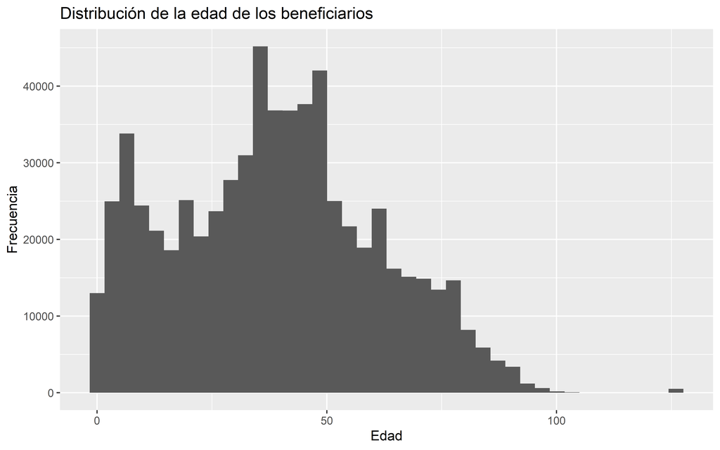

```r
ggplot(
  base_beneficiarios,
  aes(x = edad)
) +
  geom_histogram(
    bins = 40
  ) +
  labs(
    title = "Distribución de la edad de los beneficiarios",
    x = "Edad",
    y = "Frecuencia"
  )
```

La distribución de edades permitirá identificar la composición etaria de la población incluida en el estudio y detectar posibles valores extremos que requieran una revisión adicional. La edad será utilizada posteriormente como una de las variables predictoras en los modelos de clasificación. Sin embargo, vemos que hay algunas edades que superan los 110 años. Lo cuál es extremadamente raro. Optaremos por, al igual que como hicimos con las fechas futuras, dejar esos valores como NA.

Cuantificamos

```r
base_beneficiarios %>%
  filter(edad > 100) %>%
  summarise(
    beneficiarios = n()
  )
```

```
## # A tibble: 1 × 1
##   beneficiarios
##           <int>
## 1           627
```

```r
summary(base_beneficiarios$edad)
```

```
##    Min. 1st Qu.  Median    Mean 3rd Qu.    Max.    NA's
##     0.0    22.0    39.0    38.8    54.0   126.0    2957
```

```r
max(base_beneficiarios$edad, na.rm = TRUE)
```

```
## [1] 126
```

Claramente hay personas con edades de 126 años, y biológicamente hablando eso corresponde a un error de digitación. Vamos a considerar edades por debajo de los 110 años. El record mundial de edad es 122 años, por tanto, 110 años seria un buen proxy de umbral maximo. Veamos cuantos registros quedarian excluidos.

```r
base_beneficiarios %>%
  filter(edad > 110) %>%
  summarise(
    beneficiarios = n()
  )
```

```
## # A tibble: 1 × 1
##   beneficiarios
##           <int>
## 1           513
```

```r
base_beneficiarios %>%
  filter(edad > 110) %>%
  count(edad)
```

```
## # A tibble: 1 × 2
##    edad     n
##   <dbl> <int>
## 1   126   513
```

Claremente corresponde a errores, las volvemos NA_real

```r
base_beneficiarios <- base_beneficiarios %>%
  mutate(
    edad = if_else(
      edad > 110,
      NA_real_,
      edad
    )
  )
```

**Interpretación**

Se identificó un número reducido de beneficiarios con edades superiores a 110 años. Debido a que estos valores representan una fracción mínima de la población y exceden ampliamente la longevidad esperada, fueron tratados como valores faltantes con el fin de evitar que posibles errores de registro influyeran en el entrenamiento de los modelos predictivos.

Volvemos a graficar

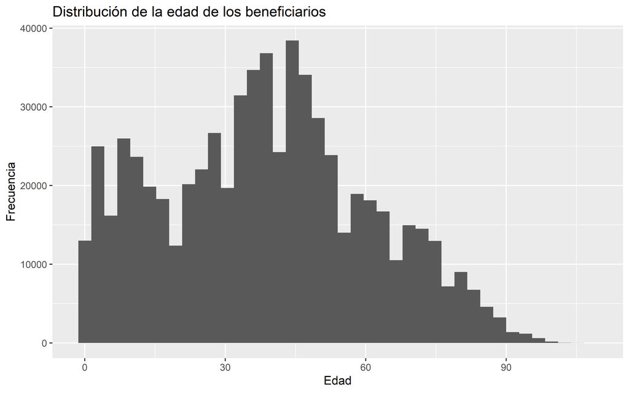

```r
ggplot(
  base_beneficiarios,
  aes(x = edad)
) +
  geom_histogram(
    bins = 40
  ) +
  labs(
    title = "Distribución de la edad de los beneficiarios",
    x = "Edad",
    y = "Frecuencia"
  )
```

Perfecto, esto es más consistente a un histograma de real lógico.

# 5. Análisis exploratorio de la base analítica

## 5.1 Balance de clases

Antes del entrenamiento de los modelos predictivos resulta fundamental conocer la distribución de la variable objetivo. En problemas de clasificación en salud es frecuente encontrar clases desbalanceadas, donde la enfermedad de interés representa únicamente una pequeña proporción de la población.

La identificación de este desbalance permitirá seleccionar posteriormente métricas de evaluación adecuadas y considerar estrategias específicas durante el entrenamiento de los modelos.

```r
base_beneficiarios %>%
  count(TEA)
```

```
## # A tibble: 2 × 2
##     TEA      n
##   <dbl>  <int>
## 1     0 652820
## 2     1    811
```

```r
tabla_tea <- base_beneficiarios %>%
  count(TEA)

knitr::kable(
  tabla_tea,
  caption = "Distribución de beneficiarios según la presencia de TEA."
)
```

Distribución de beneficiarios según la presencia de TEA.

| TEA | n |
| --- | --- |
| 0 | 652820 |
| 1 | 811 |

**Proporciones**

```r
tabla_tea <- base_beneficiarios %>%
  count(TEA) %>%
  mutate(
    porcentaje = round(100 * n / sum(n), 2)
  )

knitr::kable(
  tabla_tea,
  caption = "Distribución porcentual de la variable objetivo."
)
```

Distribución porcentual de la variable objetivo.

| TEA | n | porcentaje |
| --- | --- | --- |
| 0 | 652820 | 99.88 |
| 1 | 811 | 0.12 |

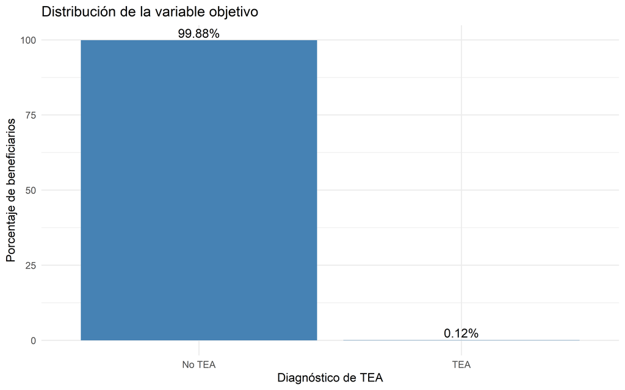

```r
ggplot(tabla_tea,
       aes(x = factor(TEA),
           y = porcentaje)) +

  geom_col(fill = "steelblue") +

  geom_text(
    aes(label = paste0(porcentaje, "%")),
    vjust = -0.3,
    size = 4
  ) +

  labs(
    title = "Distribución de la variable objetivo",
    x = "Diagnóstico de TEA",
    y = "Porcentaje de beneficiarios"
  ) +

  scale_x_discrete(labels = c("No TEA", "TEA")) +

  theme_minimal()
```

**Interpretación**

De los **653.631** beneficiarios incluidos en la base analítica, únicamente **811 (0,124%)** presentaron un diagnóstico compatible con Trastorno del Espectro Autista (TEA), mientras que **652.820 (99,876%)** no registraron dicho diagnóstico. Esta marcada diferencia evidencia un problema de desbalance extremo de clases, situación frecuente en estudios epidemiológicos donde la enfermedad de interés presenta una baja prevalencia.

Este desbalance deberá ser considerado durante el desarrollo de los modelos predictivos, ya que métricas tradicionales como la exactitud (accuracy) pueden resultar engañosas. En consecuencia, la evaluación del desempeño se apoyará principalmente en métricas como **ROC-AUC, Precision-Recall AUC (PR-AUC)**, sensibilidad y precisión, las cuales ofrecen una valoración más adecuada cuando la clase positiva representa una pequeña proporción de la población.

## 5.2 Variables demográficas

```r
tabla_sexo <- base_beneficiarios %>%
  count(sexo) %>%
  mutate(
    porcentaje = round(100 * n / sum(n), 2)
  )

knitr::kable(
  tabla_sexo,
  caption = "Distribución de los beneficiarios según el sexo."
)
```

Distribución de los beneficiarios según el sexo.

| sexo | n | porcentaje |
| --- | --- | --- |
| F | 359895 | 55.06 |
| M | 263350 | 40.29 |
| Não Informado | 30386 | 4.65 |

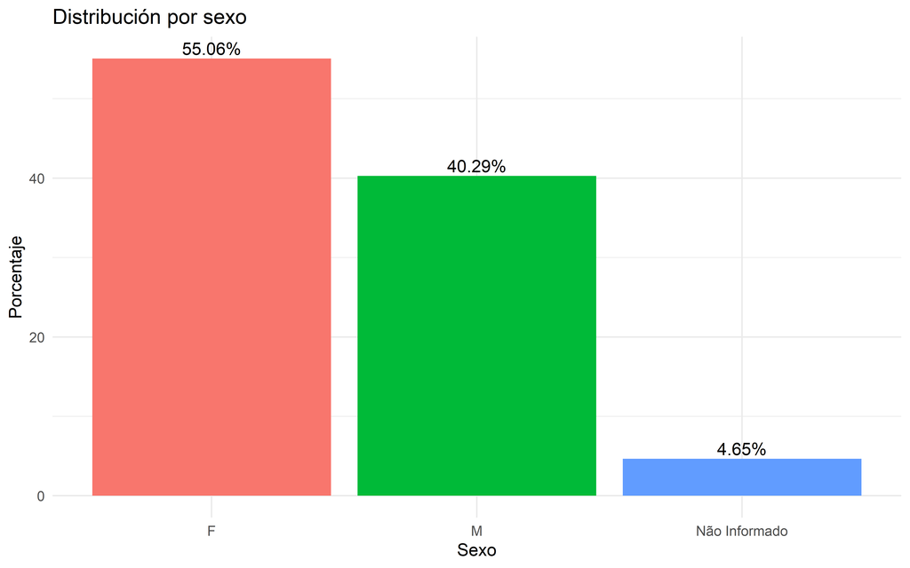

```r
ggplot(tabla_sexo,
       aes(x = sexo,
           y = porcentaje,
           fill = sexo)) +

  geom_col(show.legend = FALSE) +

  geom_text(
    aes(label = paste0(porcentaje, "%")),
    vjust = -0.3
  ) +

  labs(
    x = "Sexo",
    y = "Porcentaje",
    title = "Distribución por sexo"
  ) +

  theme_minimal()
```

## 5.3 Distribución por estado y especialidad

Además de las características demográficas de los beneficiarios, el enunciado del taller pide caracterizar la población según el estado (región del prestador hospitalario, `UF_CNES_PREST_HOSPITALAR`) y la especialidad médica (`DESC_ESPECIALIDADE`). A diferencia de la edad o el sexo, estas dos variables se registran a **nivel de utilización** (un mismo beneficiario puede recibir atención en distintos estados o con distintas especialidades a lo largo del tiempo), por lo que su distribución se calcula directamente sobre la base transaccional `datos`, antes de la agregación por beneficiario.

### 5.3.1 Distribución por estado (UF_CNES_PREST_HOSPITALAR)

```r
tabla_estado <- datos %>%
  count(UF_CNES_PREST_HOSPITALAR, sort = TRUE) %>%
  mutate(
    porcentaje = round(100 * n / sum(n), 2)
  )

knitr::kable(
  head(tabla_estado, 15),
  caption = "Estados con mayor número de utilizaciones registradas."
)
```

Estados con mayor número de utilizaciones registradas.

| UF_CNES_PREST_HOSPITALAR | n | porcentaje |
| --- | --- | --- |
| SP | 4695722 | 50.25 |
| - | 2686301 | 28.75 |
| PE | 630010 | 6.74 |
| MT | 445662 | 4.77 |
| RJ | 377041 | 4.03 |
| PR | 205164 | 2.20 |
| SC | 58452 | 0.63 |
| BA | 56280 | 0.60 |
| MG | 46360 | 0.50 |
| GO | 30161 | 0.32 |
| PA | 17868 | 0.19 |
| RS | 17031 | 0.18 |
| DF | 16130 | 0.17 |
| MS | 14743 | 0.16 |
| ES | 10719 | 0.11 |

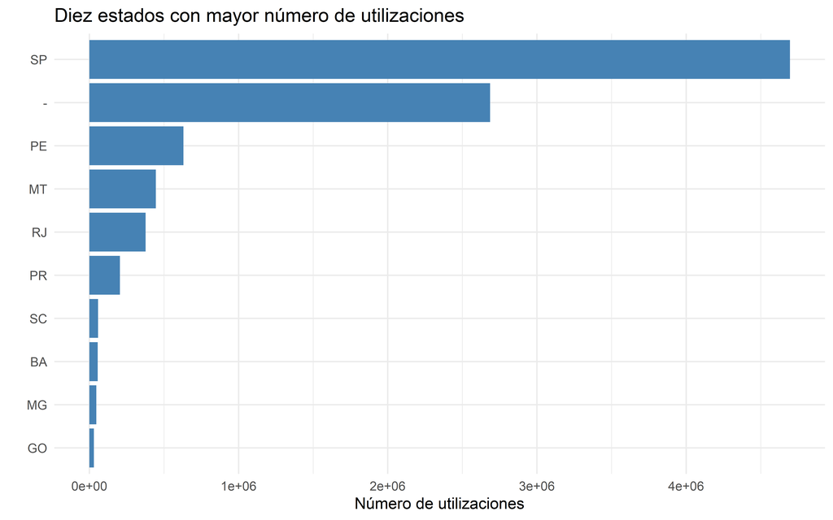

```r
ggplot(
  head(tabla_estado, 10),
  aes(
    x = reorder(UF_CNES_PREST_HOSPITALAR, n),
    y = n
  )
) +
  geom_col(fill = "steelblue") +
  coord_flip() +
  labs(
    title = "Diez estados con mayor número de utilizaciones",
    x = "",
    y = "Número de utilizaciones"
  ) +
  theme_minimal()
```

**Interpretación**

La distribución revela una concentración extrema en São Paulo (SP), que agrupa el **50,25%** de todas las utilizaciones registradas (4.695.722 de 9.345.278), seguido a distancia por Pernambuco (PE, 6,74%), Mato Grosso (MT, 4,77%) y Río de Janeiro (RJ, 4,03%). Esta concentración es consistente con la relevancia de São Paulo como principal centro económico y de infraestructura hospitalaria de Brasil, y probablemente refleja la red de prestadores de la aseguradora más que el lugar de residencia de los beneficiarios.

Un hallazgo relevante que no se había identificado en el análisis de calidad de datos de la sección 3.2 es que el **28,75%** de las utilizaciones (2.686.301 registros) tienen el estado registrado como `"-"`, es decir, sin información válida. Esta proporción es demasiado alta para ignorarse: casi tres de cada diez utilizaciones no permiten identificar en qué estado se prestó el servicio. Esto no había sido detectado por `colSums(is.na(datos))` en la sección 3.2, ya que `"-"` es un valor de texto válido y no un `NA` técnico en R. Se documenta este hallazgo como una limitación adicional de calidad de datos en la sección 11.1.

### 5.3.2 Distribución por especialidad médica

```r
tabla_especialidad <- datos %>%
  count(DESC_ESPECIALIDADE, sort = TRUE) %>%
  mutate(
    porcentaje = round(100 * n / sum(n), 2)
  )

knitr::kable(
  head(tabla_especialidad, 15),
  caption = "Especialidades médicas con mayor número de utilizaciones (toda la base)."
)
```

Especialidades médicas con mayor número de utilizaciones (toda la base).

| DESC_ESPECIALIDADE | n | porcentaje |
| --- | --- | --- |
| - | 6588625 | 70.50 |
| MEDICO CLINICO | 616722 | 6.60 |
|  | 252814 | 2.71 |
| PATOLOGIA CLÍNICA / MEDICINA LABORATORIAL | 198929 | 2.13 |
| CLINICA MÉDICA | 189748 | 2.03 |
| ANÁLISES CLÍNICAS DIVERSAS | 171697 | 1.84 |
| CIRURGIA GERAL | 82953 | 0.89 |
| PRONTO ATENDIMENTO GERAL | 76617 | 0.82 |
| CIRURGIAO / CLINICO | 74424 | 0.80 |
| OFTALMOLOGIA | 65071 | 0.70 |
| MEDICO EM RADIOLOGIA E DIAGNOSTICO POR IMAGEM | 54504 | 0.58 |
| CLINICO GERAL | 44067 | 0.47 |
| MEDICO ORTOPEDISTA E TRAUMATOLOGISTA | 42681 | 0.46 |
| TERAPIAS ESPECÍFICAS | 31535 | 0.34 |
| FISIOTERAPEUTA GERAL | 30916 | 0.33 |

Adicionalmente, dado que el TEA se caracteriza por requerir seguimiento multidisciplinario (mencionado en la Introducción), resulta útil comparar esta distribución general con la distribución de especialidades específicamente entre las utilizaciones asociadas al diagnóstico de TEA. Para ello se usa el indicador `TEA` ya construido a nivel de registro en la sección 4.1.

```r
tabla_especialidad_tea <- datos %>%
  filter(TEA == 1) %>%
  count(DESC_ESPECIALIDADE, sort = TRUE) %>%
  mutate(
    porcentaje = round(100 * n / sum(n), 2)
  )

knitr::kable(
  head(tabla_especialidad_tea, 10),
  caption = "Especialidades médicas más frecuentes en utilizaciones con diagnóstico de TEA."
)
```

Especialidades médicas más frecuentes en utilizaciones con diagnóstico de TEA.

| DESC_ESPECIALIDADE | n | porcentaje |
| --- | --- | --- |
|  | 9895 | 90.62 |
| - | 1011 | 9.26 |
| MEDICO PSIQUIATRA | 12 | 0.11 |
| CLINICO GERAL | 1 | 0.01 |

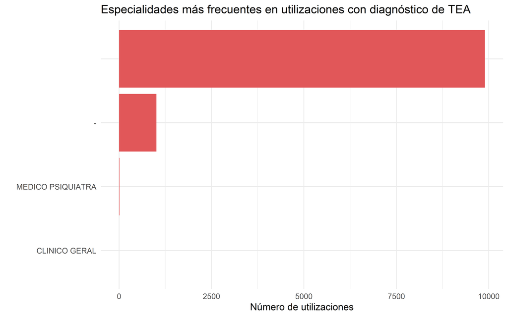

```r
ggplot(
  head(tabla_especialidad_tea, 10),
  aes(
    x = reorder(DESC_ESPECIALIDADE, n),
    y = n
  )
) +
  geom_col(fill = "#E15759") +
  coord_flip() +
  labs(
    title = "Especialidades más frecuentes en utilizaciones con diagnóstico de TEA",
    x = "",
    y = "Número de utilizaciones"
  ) +
  theme_minimal()
```

**Interpretación**

**Especialidad médica en toda la base:** `DESC_ESPECIALIDADE` presenta un nivel de valores faltantes extremadamente alto. El **70,50%** de las utilizaciones (6.588.625 registros) tienen la especialidad registrada como `"-"`, y otro **2,71%** (252.814 registros) aparece bajo una segunda categoría vacía y no identificada, para un total cercano al **73%** de registros sin especialidad utilizable. Entre las especialidades sí identificadas, MEDICO CLINICO es la más frecuente (6,60%), seguida de PATOLOGIA CLÍNICA/MEDICINA LABORATORIAL (2,13%) y CLINICA MÉDICA (2,03%).

**Especialidad médica en utilizaciones con TEA:** el resultado es todavía más marcado. Del total de utilizaciones con diagnóstico de TEA, el **90,62%** no tiene especialidad identificada bajo la primera categoría vacía y otro **9,26%** aparece como `"-"`; es decir, el **99,88%** de las utilizaciones con TEA carecen de una especialidad médica utilizable en `DESC_ESPECIALIDADE`. Solamente 12 registros (0,11%) están etiquetados como MEDICO PSIQUIATRA y 1 registro (0,01%) como CLINICO GERAL.

Este resultado **contradice la hipótesis planteada inicialmente** en esta sección, donde se esperaba encontrar una concentración de especialidades asociadas al diagnóstico y seguimiento del TEA (psiquiatría, neurología, terapias, etc.). En la práctica, el hallazgo real es que `DESC_ESPECIALIDADE` no es una variable utilizable para caracterizar el tipo de atención que reciben los beneficiarios con TEA, debido a su altísimo nivel de datos faltantes específicamente en este subgrupo. Esto constituye una limitación importante de calidad de datos: aunque `especialidades_distintas` (el conteo de especialidades distintas por beneficiario, construido en la sección 4.2.3) sí resultó ser una variable relevante en los modelos predictivos (sección 9.2) y en el modelo de costo esperado (sección 10.6), este hallazgo sugiere que dicha importancia podría estar capturando, en parte, un patrón de registro/documentación diferencial entre beneficiarios con y sin TEA, y no únicamente la diversidad clínica real de la atención recibida. Se documenta esta observación en la sección 11.1.

## 5.4 Tipo de beneficiario

```r
tabla_tipo <- base_beneficiarios %>%
  count(tipo_beneficiario) %>%
  mutate(
    porcentaje = round(100 * n / sum(n),2)
  )

knitr::kable(
  tabla_tipo,
  caption = "Distribución según el tipo de beneficiario."
)
```

Distribución según el tipo de beneficiario.

| tipo_beneficiario | n | porcentaje |
| --- | --- | --- |
| AGREGADO | 5905 | 0.90 |
| CONJUGE | 1274 | 0.19 |
| DEPENDENTE | 271239 | 41.50 |
| FILHO | 1107 | 0.17 |
| IGNORADO | 185 | 0.03 |
| MAE | 1 | 0.00 |
| Não Informado | 30571 | 4.68 |
| OUTROS | 4849 | 0.74 |
| TITULAR | 338499 | 51.79 |
| TUTELADO | 1 | 0.00 |

## 5.5 Comparación de las características según la presencia de TEA

Antes del entrenamiento de los modelos predictivos resulta conveniente explorar si existen diferencias entre los beneficiarios con y sin diagnóstico de Trastorno del Espectro Autista. Este análisis permitirá identificar variables potencialmente discriminantes y facilitará la interpretación posterior de los modelos de clasificación.

### 5.5.1 Edad según la presencia de TEA

```r
edad_tea <- base_beneficiarios %>%
  group_by(TEA) %>%
  summarise(
    Beneficiarios = n(),
    Edad_media = round(mean(edad, na.rm = TRUE), 2),
    Edad_mediana = median(edad, na.rm = TRUE),
    Edad_minima = min(edad, na.rm = TRUE),
    Edad_maxima = max(edad, na.rm = TRUE),
    .groups = "drop"
  )

knitr::kable(
  edad_tea,
  caption = "Resumen de la edad según la presencia de TEA."
)
```

Resumen de la edad según la presencia de TEA.

| TEA | Beneficiarios | Edad_media | Edad_mediana | Edad_minima | Edad_maxima |
| --- | --- | --- | --- | --- | --- |
| 0 | 652820 | 38.77 | 39 | 0 | 108 |
| 1 | 811 | 9.16 | 8 | 1 | 73 |

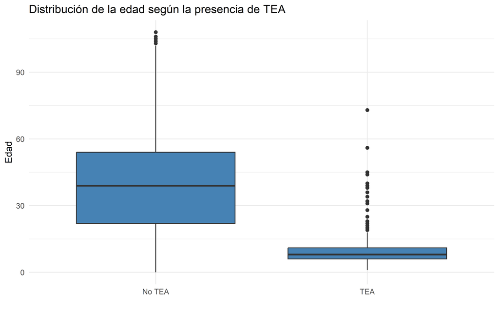

```r
ggplot(
  base_beneficiarios,
  aes(
    x = factor(TEA),
    y = edad
  )
) +
  geom_boxplot(fill = "steelblue") +
  scale_x_discrete(labels = c("No TEA", "TEA")) +
  labs(
    x = "",
    y = "Edad",
    title = "Distribución de la edad según la presencia de TEA"
  ) +
  theme_minimal()
```

**Interpretación**

Se observaron diferencias importantes en la distribución de la edad entre ambos grupos. Los beneficiarios sin diagnóstico de TEA presentaron una edad media de **38,77 años**, mientras que los beneficiarios con TEA tuvieron una edad media de **9,16 años**. Asimismo, la mediana de edad fue de **39 años** en el grupo sin TEA y de **8 años** en el grupo con TEA. Estos resultados son consistentes con la naturaleza del trastorno, cuyo diagnóstico suele realizarse durante la infancia, por lo que la población con TEA se concentra principalmente en edades tempranas.

### 5.5.2 Sexo según la presencia de TEA

```r
sexo_tea <- base_beneficiarios %>%
  count(TEA, sexo) %>%
  group_by(TEA) %>%
  mutate(
    porcentaje = round(100 * n / sum(n), 2)
  )

knitr::kable(
  sexo_tea,
  caption = "Distribución del sexo según la presencia de TEA."
)
```

Distribución del sexo según la presencia de TEA.

| TEA | sexo | n | porcentaje |
| --- | --- | --- | --- |
| 0 | F | 359672 | 55.10 |
| 0 | M | 262768 | 40.25 |
| 0 | Não Informado | 30380 | 4.65 |
| 1 | F | 223 | 27.50 |
| 1 | M | 582 | 71.76 |
| 1 | Não Informado | 6 | 0.74 |

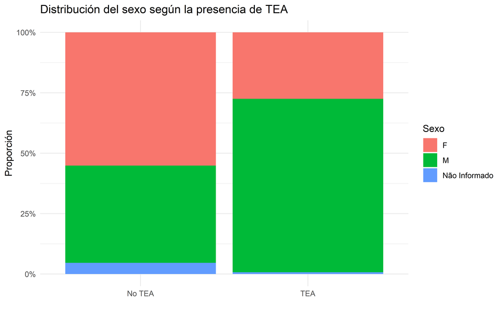

```r
ggplot(
  sexo_tea,
  aes(
    x = factor(TEA),
    y = porcentaje,
    fill = sexo
  )
) +
  geom_col(position = "fill") +
  scale_y_continuous(labels = scales::percent) +
  scale_x_discrete(labels = c("No TEA", "TEA")) +
  labs(
    x = "",
    y = "Proporción",
    fill = "Sexo",
    title = "Distribución del sexo según la presencia de TEA"
  ) +
  theme_minimal()
```

**Interpretación**

La distribución por sexo evidenció diferencias claras entre ambos grupos. En la población sin TEA, el **55,10 %** correspondió al sexo femenino y el **40,25 %** al sexo masculino. En contraste, entre los beneficiarios con TEA el **71,76 %** fueron hombres y el **27,50 %** mujeres. Esta distribución coincide con la literatura científica, donde el Trastorno del Espectro Autista presenta una mayor frecuencia de diagnóstico en hombres que en mujeres.

### 5.5.3 Tipo de beneficiario según la presencia de TEA

```r
tipo_tea <- base_beneficiarios %>%
  count(TEA, tipo_beneficiario) %>%
  group_by(TEA) %>%
  mutate(
    porcentaje = round(100 * n / sum(n), 2)
  )

knitr::kable(
  tipo_tea,
  caption = "Tipo de beneficiario según la presencia de TEA."
)
```

Tipo de beneficiario según la presencia de TEA.

| TEA | tipo_beneficiario | n | porcentaje |
| --- | --- | --- | --- |
| 0 | AGREGADO | 5904 | 0.90 |
| 0 | CONJUGE | 1274 | 0.20 |
| 0 | DEPENDENTE | 270802 | 41.48 |
| 0 | FILHO | 1107 | 0.17 |
| 0 | IGNORADO | 185 | 0.03 |
| 0 | MAE | 1 | 0.00 |
| 0 | Não Informado | 30565 | 4.68 |
| 0 | OUTROS | 4849 | 0.74 |
| 0 | TITULAR | 338132 | 51.80 |
| 0 | TUTELADO | 1 | 0.00 |
| 1 | AGREGADO | 1 | 0.12 |
| 1 | DEPENDENTE | 437 | 53.88 |
| 1 | Não Informado | 6 | 0.74 |
| 1 | TITULAR | 367 | 45.25 |

**Interpretación**

También se observaron diferencias en la composición según el tipo de beneficiario. En la población sin TEA predominó la categoría **Titular (51,80 %)**, seguida por **Dependiente (41,48 %)**. Por el contrario, entre los beneficiarios con TEA la categoría más frecuente fue **Dependiente (53,88 %)**, seguida de **Titular (45,25 %)**. Este comportamiento resulta coherente con la menor edad observada en la población con TEA, ya que una mayor proporción de estos beneficiarios aún depende de un titular del plan de salud.

## 5.6 Comparación de la utilización de servicios de salud

En esta sección se evaluarán las diferencias en la utilización de los servicios de salud entre beneficiarios con y sin diagnóstico de TEA. Se analizarán variables relacionadas con el número de atenciones, diversidad de procedimientos, hospitalizaciones, ingresos a unidades de cuidados intensivos y costos asociados, con el propósito de identificar patrones de utilización potencialmente útiles para el desarrollo de los modelos predictivos.

### 5.6.1 Número de utilizaciones

```r
utilizacion_tea <- base_beneficiarios %>%
  group_by(TEA) %>%
  summarise(
    Beneficiarios = n(),
    Media = round(mean(numero_utilizaciones), 2),
    Mediana = median(numero_utilizaciones),
    Minimo = min(numero_utilizaciones),
    Maximo = max(numero_utilizaciones),
    .groups = "drop"
  )

knitr::kable(
  utilizacion_tea,
  caption = "Número de utilizaciones según la presencia de TEA."
)
```

Número de utilizaciones según la presencia de TEA.

| TEA | Beneficiarios | Media | Mediana | Minimo | Maximo |
| --- | --- | --- | --- | --- | --- |
| 0 | 652820 | 3.44 | 2 | 1 | 110 |
| 1 | 811 | 7.64 | 7 | 1 | 65 |

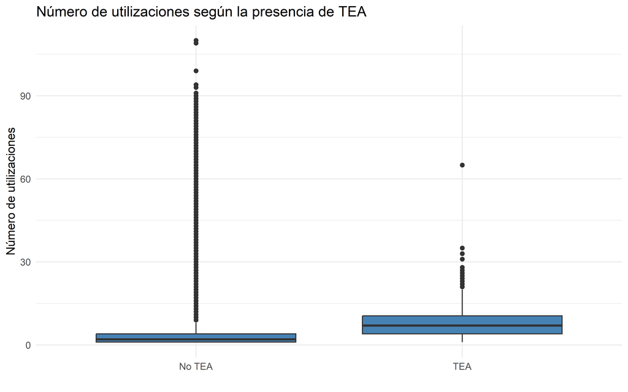

```r
ggplot(
  base_beneficiarios,
  aes(
    x = factor(TEA),
    y = numero_utilizaciones
  )
) +
  geom_boxplot(fill = "steelblue") +
  scale_x_discrete(labels = c("No TEA","TEA")) +
  labs(
    x = "",
    y = "Número de utilizaciones",
    title = "Número de utilizaciones según la presencia de TEA"
  ) +
  theme_minimal()
```

**Interpretación**

Los beneficiarios con diagnóstico de TEA presentaron una mayor utilización de los servicios de salud en comparación con aquellos sin diagnóstico. Mientras que la población sin TEA registró un promedio de **3,44 utilizaciones** por beneficiario (mediana = 2), los beneficiarios con TEA alcanzaron un promedio de **7,64 utilizaciones** (mediana = 7). Estos resultados indican que las personas con TEA utilizan los servicios de salud con una frecuencia considerablemente mayor, lo cual es consistente con la necesidad de controles médicos periódicos, terapias especializadas y seguimiento multidisciplinario característicos de esta condición.

### 5.6.2 Número de procedimientos distintos

```r
procedimientos_tea <- base_beneficiarios %>%
  group_by(TEA) %>%
  summarise(
    Beneficiarios = n(),
    Media = round(mean(procedimientos_distintos), 2),
    Mediana = median(procedimientos_distintos),
    Minimo = min(procedimientos_distintos),
    Maximo = max(procedimientos_distintos),
    .groups = "drop"
  )

knitr::kable(
  procedimientos_tea,
  caption = "Número de procedimientos distintos según la presencia de TEA."
)
```

Número de procedimientos distintos según la presencia de TEA.

| TEA | Beneficiarios | Media | Mediana | Minimo | Maximo |
| --- | --- | --- | --- | --- | --- |
| 0 | 652820 | 7.86 | 3 | 1 | 149 |
| 1 | 811 | 3.70 | 2 | 1 | 64 |

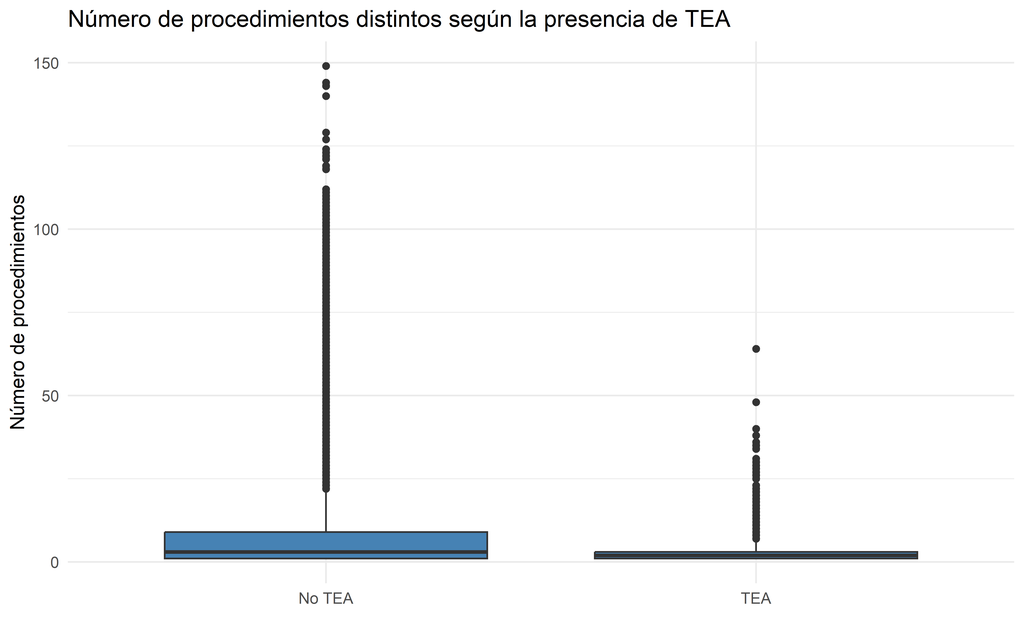

```r
ggplot(
  base_beneficiarios,
  aes(
    x = factor(TEA),
    y = procedimientos_distintos
  )
) +
  geom_boxplot(fill = "steelblue") +
  scale_x_discrete(labels = c("No TEA","TEA")) +
  labs(
    x = "",
    y = "Número de procedimientos",
    title = "Número de procedimientos distintos según la presencia de TEA"
  ) +
  theme_minimal()
```

**Interpretación**

En promedio, los beneficiarios sin diagnóstico de TEA registraron un mayor número de procedimientos distintos **(7,86)** que los beneficiarios con TEA **(3,70)**. Esta diferencia sugiere que, aunque las personas con TEA utilizan con mayor frecuencia los servicios de salud, dicha utilización tiende a concentrarse en un conjunto reducido de procedimientos repetitivos, relacionados con terapias y controles especializados, mientras que la población general presenta una mayor diversidad de procedimientos médicos a lo largo del periodo analizado.

### 5.6.3 Número de especialidades distintas

```r
especialidades_tea <- base_beneficiarios %>%
  group_by(TEA) %>%
  summarise(
    Beneficiarios = n(),
    Media = round(mean(especialidades_distintas), 2),
    Mediana = median(especialidades_distintas),
    Minimo = min(especialidades_distintas),
    Maximo = max(especialidades_distintas),
    .groups = "drop"
  )

knitr::kable(
  especialidades_tea,
  caption = "Número de especialidades distintas según la presencia de TEA."
)
```

Número de especialidades distintas según la presencia de TEA.

| TEA | Beneficiarios | Media | Mediana | Minimo | Maximo |
| --- | --- | --- | --- | --- | --- |
| 0 | 652820 | 1.37 | 1 | 1 | 18 |
| 1 | 811 | 1.00 | 1 | 1 | 3 |

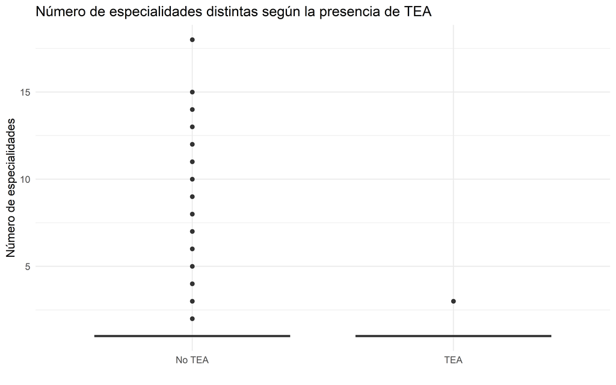

```r
ggplot(
  base_beneficiarios,
  aes(
    x = factor(TEA),
    y = especialidades_distintas
  )
) +
  geom_boxplot(fill = "steelblue") +
  scale_x_discrete(labels = c("No TEA","TEA")) +
  labs(
    x = "",
    y = "Número de especialidades",
    title = "Número de especialidades distintas según la presencia de TEA"
  ) +
  theme_minimal()
```

**Interpretación**

También se observaron diferencias en el número de especialidades médicas utilizadas. Los beneficiarios sin TEA consultaron, en promedio, **1,37 especialidades**, mientras que los beneficiarios con TEA utilizaron aproximadamente una **única especialidad** durante el periodo de estudio. Este resultado es consistente con la atención más focalizada que caracteriza al seguimiento del TEA, donde el manejo suele concentrarse en un número reducido de profesionales especializados.

### 5.6.4 Hospitalizaciones

```r
hospitalizaciones_tea <- base_beneficiarios %>%
  group_by(TEA) %>%
  summarise(
    Beneficiarios = n(),
    Media = round(mean(hospitalizaciones), 2),
    Mediana = median(hospitalizaciones),
    Minimo = min(hospitalizaciones),
    Maximo = max(hospitalizaciones),
    .groups = "drop"
  )

knitr::kable(
  hospitalizaciones_tea,
  caption = "Número de hospitalizaciones según la presencia de TEA."
)
```

Número de hospitalizaciones según la presencia de TEA.

| TEA | Beneficiarios | Media | Mediana | Minimo | Maximo |
| --- | --- | --- | --- | --- | --- |
| 0 | 652820 | 0.07 | 0 | 0 | 110 |
| 1 | 811 | 0.01 | 0 | 0 | 3 |

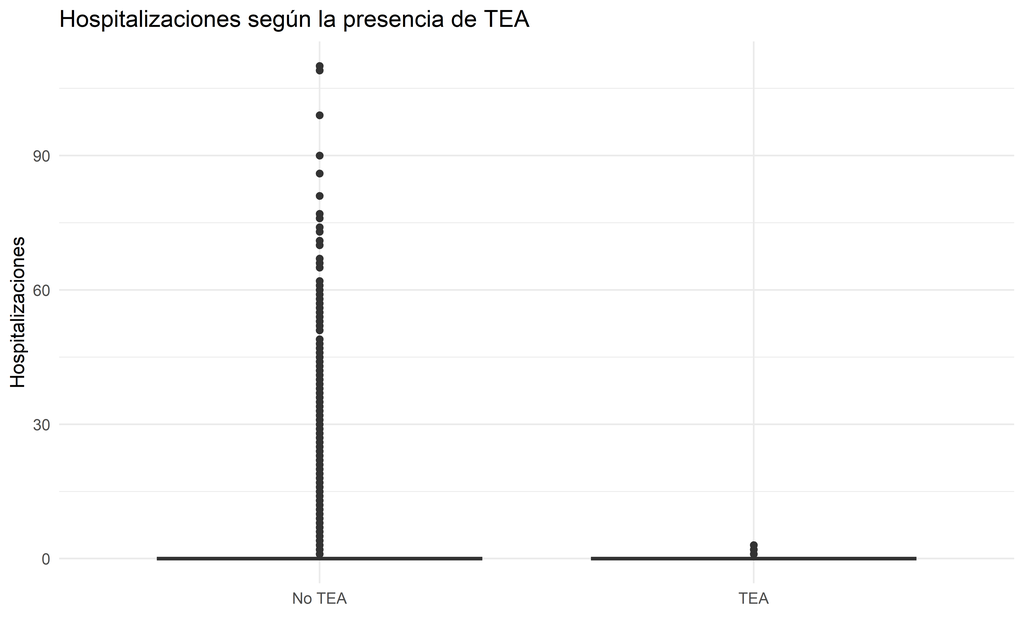

```r
ggplot(
  base_beneficiarios,
  aes(
    x = factor(TEA),
    y = hospitalizaciones
  )
) +
  geom_boxplot(fill = "steelblue") +
  scale_x_discrete(labels = c("No TEA","TEA")) +
  labs(
    x = "",
    y = "Hospitalizaciones",
    title = "Hospitalizaciones según la presencia de TEA"
  ) +
  theme_minimal()
```

**Interpretación**

Las hospitalizaciones fueron poco frecuentes en ambos grupos. No obstante, la población sin TEA presentó un promedio ligeramente superior **(0,07 hospitalizaciones por beneficiario)** en comparación con los beneficiarios con TEA **(0,01)**. La mediana fue igual a cero en ambos grupos, indicando que la mayoría de los beneficiarios no requirió hospitalización durante el periodo analizado. Este resultado sugiere que la presencia de TEA, por sí sola, no se asocia necesariamente con una mayor utilización de servicios hospitalarios.

### 5.6.5 Ingresos a UTI

```r
uti_tea <- base_beneficiarios %>%
  group_by(TEA) %>%
  summarise(
    Beneficiarios = n(),
    Media = round(mean(ingresos_uti), 2),
    Mediana = median(ingresos_uti),
    Minimo = min(ingresos_uti),
    Maximo = max(ingresos_uti),
    .groups = "drop"
  )

knitr::kable(
  uti_tea,
  caption = "Número de ingresos a UTI según la presencia de TEA."
)
```

Número de ingresos a UTI según la presencia de TEA.

| TEA | Beneficiarios | Media | Mediana | Minimo | Maximo |
| --- | --- | --- | --- | --- | --- |
| 0 | 652820 | 0.01 | 0 | 0 | 71 |
| 1 | 811 | 0.00 | 0 | 0 | 3 |

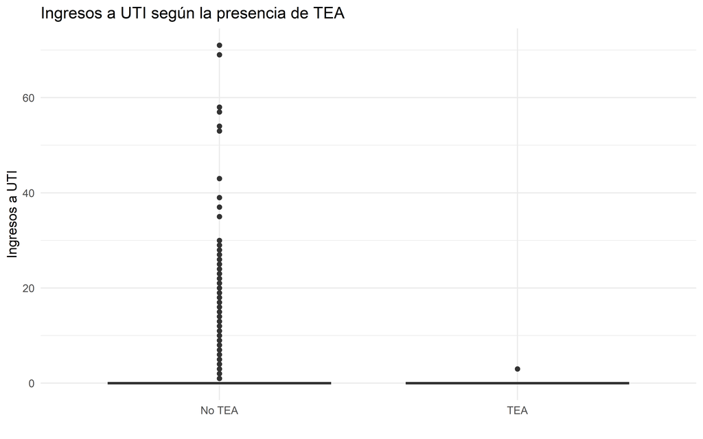

```r
ggplot(
  base_beneficiarios,
  aes(
    x = factor(TEA),
    y = ingresos_uti
  )
) +
  geom_boxplot(fill = "steelblue") +
  scale_x_discrete(labels = c("No TEA","TEA")) +
  labs(
    x = "",
    y = "Ingresos a UTI",
    title = "Ingresos a UTI según la presencia de TEA"
  ) +
  theme_minimal()
```

**Interpretación**

Los ingresos a unidades de cuidados intensivos fueron eventos muy poco frecuentes en toda la población estudiada. Tanto los beneficiarios con TEA como aquellos sin diagnóstico presentaron una mediana igual a cero, y los promedios fueron cercanos a cero en ambos grupos. Estos resultados indican que los ingresos a UTI no constituyen una característica diferencial entre las dos poblaciones y probablemente tendrán una capacidad limitada para discriminar la presencia de TEA dentro de los modelos predictivos.

## 5.7 Análisis de valores extremos en los costos

Las variables económicas suelen presentar distribuciones altamente asimétricas debido a que un reducido número de beneficiarios concentra una proporción importante del gasto en salud. Antes de incorporar estas variables a los modelos predictivos, resulta conveniente explorar su distribución e identificar posibles valores extremos que puedan influir sobre el entrenamiento de los algoritmos.

### 5.7.1 Valores extremos en VALOR_UTILIZACAO a nivel de registro

El enunciado del taller pide explícitamente revisar los valores extremos de `VALOR_UTILIZACAO`, la variable de costo tal como aparece en la base transaccional original (una fila por utilización/procedimiento). Este análisis se realiza *antes* de agregar la información por beneficiario, ya que un procedimiento individual inusualmente costoso puede diluirse una vez se agregan todos los registros de un mismo beneficiario en `costo_total`.

```r
summary(datos$VALOR_UTILIZACAO)
```

```
##      Min.   1st Qu.    Median      Mean   3rd Qu.      Max.
## -27537.23      4.56     17.39    106.85     73.75 628388.67
```

```r
quantile(
  datos$VALOR_UTILIZACAO,
  probs = c(0.50, 0.90, 0.95, 0.99, 0.999),
  na.rm = TRUE
)
```

```
##     50%     90%     95%     99%   99.9%
##   17.39  140.00  268.80 1222.44 9457.30
```

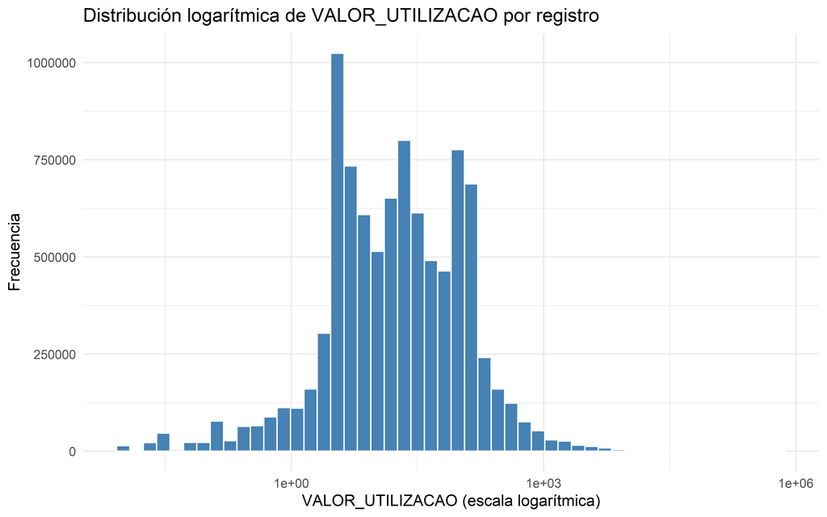

```r
ggplot(
  datos,
  aes(x = VALOR_UTILIZACAO)
) +
  geom_histogram(
    bins = 50,
    fill = "steelblue",
    color = "white"
  ) +
  scale_x_log10() +
  labs(
    title = "Distribución logarítmica de VALOR_UTILIZACAO por registro",
    x = "VALOR_UTILIZACAO (escala logarítmica)",
    y = "Frecuencia"
  ) +
  theme_minimal()
```

```r
datos %>%
  summarise(
    registros_negativos = sum(VALOR_UTILIZACAO < 0, na.rm = TRUE),
    porcentaje_negativos = round(100 * mean(VALOR_UTILIZACAO < 0, na.rm = TRUE), 4),
    registros_cero = sum(VALOR_UTILIZACAO == 0, na.rm = TRUE),
    porcentaje_cero = round(100 * mean(VALOR_UTILIZACAO == 0, na.rm = TRUE), 4)
  )
```

```
##   registros_negativos porcentaje_negativos registros_cero porcentaje_cero
## 1                3001               0.0321          70394          0.7533
```

**Interpretación**

El resumen de `VALOR_UTILIZACAO` a nivel de registro confirma la fuerte asimetría positiva ya identificada en `costo_total` agregado: la mediana (**17,39**) es sustancialmente menor que la media (**106,85**), y el valor máximo (**628.388,67**) es varios órdenes de magnitud superior a la mediana, reflejando un pequeño número de procedimientos individuales extraordinariamente costosos —probablemente asociados a internaciones, cirugías o procedimientos de alta complejidad— frente a la mayoría de utilizaciones, cuyo costo típico (mediana) es de apenas $17,39. El histograma en escala logarítmica confirma esta forma: la masa de la distribución se concentra entre 1 y 1.000, con una cola derecha larga y dispersa que se extiende hasta valores cercanos a $1.000.000, consistente con el máximo observado.

### 5.7.2 Costo total

```r
summary(base_beneficiarios$costo_total)
```

```
##      Min.   1st Qu.    Median      Mean   3rd Qu.      Max.
##   -3495.8     138.7     329.5    1527.7     797.5 1905829.6
```

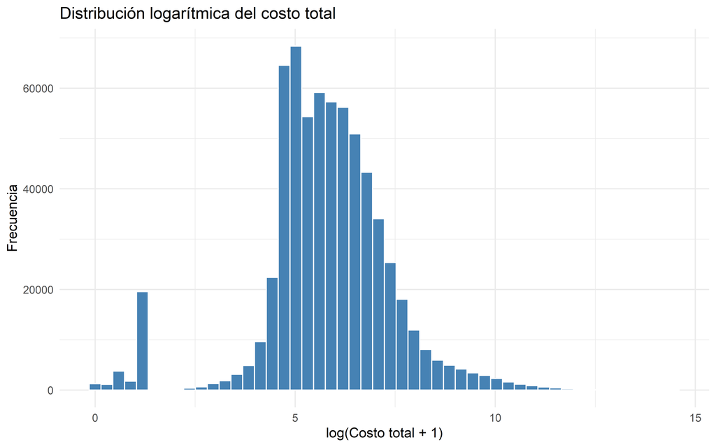

```r
ggplot(
  base_beneficiarios,
  aes(
    x = log1p(costo_total)
  )
) +
  geom_histogram(
    bins = 50,
    fill = "steelblue",
    color = "white"
  ) +
  labs(
    title = "Distribución logarítmica del costo total",
    x = "log(Costo total + 1)",
    y = "Frecuencia"
  ) +
  theme_minimal()
```

```r
quantile(
  base_beneficiarios$costo_total,
  probs = c(0.50, 0.90, 0.95, 0.99, 0.999),
  na.rm = TRUE
)
```

```
##        50%        90%        95%        99%      99.9%
##    329.530   1913.460   3936.185  23060.290 124011.503
```

**Interpretación**

#### 5.7.2.1 Datos atípicos

Cuantificamos los datos atipicos

```r
base_beneficiarios %>%
  summarise(
    negativos = sum(costo_total < 0),
    porcentaje = round(
      100 * mean(costo_total < 0),
      4
    )
  )
```

```
## # A tibble: 1 × 2
##   negativos porcentaje
##       <int>      <dbl>
## 1         1     0.0002
```

```r
summary(
  base_beneficiarios$costo_total[
    base_beneficiarios$costo_total < 0
  ]
)
```

```
##    Min. 1st Qu.  Median    Mean 3rd Qu.    Max.
##   -3496   -3496   -3496   -3496   -3496   -3496
```

Miramos algunos registros

```r
base_beneficiarios %>%
  filter(costo_total < 0) %>%
  select(
    CHAVE_FUNCIONAL,
    costo_total,
    numero_utilizaciones,
    procedimientos_distintos
  ) %>%
  head(20)
```

```
## # A tibble: 1 × 4
##   CHAVE_FUNCIONAL        costo_total numero_utilizaciones procedimientos_disti…¹
##   <chr>                        <dbl>                <int>                  <int>
## 1 14759f5b-17f7-4571-b7…      -3496.                    4                      1
## # ℹ abbreviated name: ¹procedimientos_distintos
```

**Interpretación**

```r
base_beneficiarios <- base_beneficiarios %>%
  filter(costo_total >= 0)
```

```r
dim(base_beneficiarios)
```

```
## [1] 653630     15
```

#### 5.7.2.2 Guardado de la base analítica curada

Una vez finalizadas las etapas de limpieza, construcción de variables y análisis inicial de calidad, se guarda la base analítica curada. Este archivo contiene una fila por beneficiario y será utilizado como punto de partida para la etapa de modelamiento predictivo.

```r
saveRDS(
  base_beneficiarios,
  "base_beneficiarios_curada.rds"
)
```

# 6. Modelamiento predictivo

## 6.1 Cargar la base analítica curada

```r
base_beneficiarios <- readRDS(
  "base_beneficiarios_curada.rds"
)
```

```r
# Verificar la dimensión de la base

dim(base_beneficiarios)
```

```
## [1] 653630     15
```

```r
# Verificar valores faltantes

colSums(is.na(base_beneficiarios))
```

```
##          CHAVE_FUNCIONAL                      TEA                     sexo
##                        0                        0                        0
##        tipo_beneficiario         fecha_nacimiento         numero_registros
##                        0                     2957                        0
##     numero_utilizaciones procedimientos_distintos especialidades_distintas
##                        0                        0                        0
##        hospitalizaciones             ingresos_uti              costo_total
##                        0                        0                        0
##           costo_promedio             costo_maximo                     edad
##                        0                        0                     3470
```

## 6.2 Preparación para el modelamiento

Antes de entrenar los modelos es necesario seleccionar las variables predictoras y dividir la información en conjuntos de entrenamiento y prueba. Esta separación permite evaluar el desempeño de los modelos sobre observaciones no utilizadas durante el entrenamiento, reduciendo el riesgo de sobreajuste (overfitting).

Seleccionamos las variables del modelo

```r
modelo <- base_beneficiarios %>%
  select(
    TEA,
    edad,
    sexo,
    tipo_beneficiario,
    numero_utilizaciones,
    procedimientos_distintos,
    especialidades_distintas,
    hospitalizaciones,
    ingresos_uti,
    costo_total,
    costo_promedio,
    costo_maximo
  )
```

Verificamos nuevamente

```r
glimpse(modelo)
```

```
## Rows: 653,630
## Columns: 12
## $ TEA                      <dbl> 0, 0, 0, 0, 0, 0, 0, 0, 0, 0, 0, 0, 0, 0, 0, …
## $ edad                     <dbl> 87, 44, 38, 46, 25, 10, 24, 23, 0, 42, 37, 42…
## $ sexo                     <chr> "M", "F", "M", "M", "F", "F", "F", "F", "F", …
## $ tipo_beneficiario        <chr> "TITULAR", "DEPENDENTE", "TITULAR", "TITULAR"…
## $ numero_utilizaciones     <int> 1, 1, 1, 1, 2, 1, 7, 15, 7, 14, 2, 5, 1, 16, …
## $ procedimientos_distintos <int> 2, 3, 1, 1, 2, 2, 28, 4, 2, 6, 1, 23, 8, 1, 3…
## $ especialidades_distintas <int> 1, 1, 1, 1, 2, 1, 1, 1, 1, 1, 1, 1, 1, 1, 1, …
## $ hospitalizaciones        <int> 0, 0, 0, 0, 0, 0, 0, 0, 0, 0, 0, 0, 0, 0, 0, …
## $ ingresos_uti             <int> 0, 0, 0, 0, 0, 0, 0, 0, 0, 0, 0, 0, 0, 0, 0, …
## $ costo_total              <dbl> 165.01, 229.29, 100.00, 2.56, 299.12, 165.00,…
## $ costo_promedio           <dbl> 41.25250, 76.43000, 100.00000, 2.56000, 149.5…
## $ costo_maximo             <dbl> 64.68, 180.00, 100.00, 2.56, 234.12, 115.00, …
```

Revisamos nuevamente los valores faltantes

```r
colSums(is.na(modelo))
```

```
##                      TEA                     edad                     sexo
##                        0                     3470                        0
##        tipo_beneficiario     numero_utilizaciones procedimientos_distintos
##                        0                        0                        0
## especialidades_distintas        hospitalizaciones             ingresos_uti
##                        0                        0                        0
##              costo_total           costo_promedio             costo_maximo
##                        0                        0                        0
```

**Interpretación** Después de la selección de variables, la base utilizada para el modelamiento quedó conformada únicamente por aquellas características consideradas relevantes para la predicción del TEA. Se verificó nuevamente la presencia de valores faltantes con el fin de garantizar que todos los algoritmos pudieran entrenarse sin inconvenientes. Finalmente arreglamos la variable edad para no tener valores NA que puedan afectar el análisis.

```r
modelo <- modelo %>%
  drop_na()
```

```r
dim(modelo)
```

```
## [1] 650160     12
```

```r
colSums(is.na(modelo))
```

```
##                      TEA                     edad                     sexo
##                        0                        0                        0
##        tipo_beneficiario     numero_utilizaciones procedimientos_distintos
##                        0                        0                        0
## especialidades_distintas        hospitalizaciones             ingresos_uti
##                        0                        0                        0
##              costo_total           costo_promedio             costo_maximo
##                        0                        0                        0
```

## 6.3 División de los datos

Con el fin de evaluar la capacidad de generalización de los modelos predictivos, la base analítica se dividió en un conjunto de entrenamiento (70 %) y un conjunto de prueba (30 %). La partición se realizó de manera estratificada respecto a la variable objetivo (TEA), garantizando que la proporción de beneficiarios con y sin diagnóstico se mantuviera aproximadamente constante en ambos conjuntos.

```r
set.seed(123)

indice_train <- createDataPartition(
  modelo$TEA,
  p = 0.70,
  list = FALSE
)

train <- modelo[indice_train, ]

test <- modelo[-indice_train, ]
```

```r
dim(train)
```

```
## [1] 455112     12
```

```r
dim(test)
```

```
## [1] 195048     12
```

```r
prop.table(table(train$TEA))
```

```
##
##           0           1
## 0.998747561 0.001252439
```

```r
prop.table(table(test$TEA))
```

```
##
##           0           1
## 0.998774661 0.001225339
```

Vemos que tanto *train* como *test* tiene el mismo porcentaje de personas con **TEA (1)** que sin **TEA (0)** La partición estratificada permitió conservar prácticamente la misma prevalencia del TEA en los conjuntos de entrenamiento y prueba, evitando introducir sesgos derivados del proceso de muestreo.

## 6.4 Validación cruzada

```r
control <- trainControl(

  method = "cv",

  number = 5,

  classProbs = TRUE,

  summaryFunction = twoClassSummary,

  savePredictions = TRUE

)
```

Cambiamos la variable respuesta

```r
train$TEA <- factor(

  train$TEA,

  levels = c(0,1),

  labels = c("NoTEA","TEA")

)

test$TEA <- factor(

  test$TEA,

  levels = c(0,1),

  labels = c("NoTEA","TEA")

)
```

# 7. Análisis supervisado

## 7.1 Árbol de decisión

El primer algoritmo utilizado corresponde a un **árbol de decisión (Classification and Regression Tree, CART)**. Este método clasifica las observaciones mediante una secuencia de reglas de decisión construidas a partir de las variables predictoras, generando un modelo fácilmente interpretable y ampliamente utilizado como línea base en problemas de clasificación.

```r
colSums(is.na(train))
```

```
##                      TEA                     edad                     sexo
##                        0                        0                        0
##        tipo_beneficiario     numero_utilizaciones procedimientos_distintos
##                        0                        0                        0
## especialidades_distintas        hospitalizaciones             ingresos_uti
##                        0                        0                        0
##              costo_total           costo_promedio             costo_maximo
##                        0                        0                        0
```

```r
set.seed(123)

modelo_cart <- train(

  TEA ~ .,

  data = train,

  method = "rpart",

  metric = "ROC",

  trControl = control

)
```

```r
modelo_cart
```

```
## CART
##
## 455112 samples
##     11 predictor
##      2 classes: 'NoTEA', 'TEA'
##
## No pre-processing
## Resampling: Cross-Validated (5 fold)
## Summary of sample sizes: 364090, 364090, 364089, 364090, 364089
## Resampling results across tuning parameters:
##
##   cp           ROC        Sens       Spec
##   0.002456140  0.9089077  0.9998658  0.10701754
##   0.002506266  0.9089077  0.9998658  0.10701754
##   0.003007519  0.8324768  0.9999098  0.06666667
##
## ROC was used to select the optimal model using the largest value.
## The final value used for the model was cp = 0.002506266.
```

**Interpretación**

El árbol de decisión fue entrenado utilizando validación cruzada de cinco particiones y optimizando el área bajo la curva ROC (ROC-AUC). Durante el entrenamiento, el algoritmo seleccionó automáticamente el parámetro de complejidad (cp) que produjo el mejor desempeño promedio sobre los conjuntos de validación.

```r
#Cargamos los paquetes de arboles de decisión
library(rpart.plot)
library(rpart)
```

```r
rpart.plot(
  modelo_cart$finalModel,
  type = 4,
  extra = 104,
  fallen.leaves = TRUE,
  box.palette = "GnBu"
)
```

[figure not shown]

### 7.1.1 Predicciones del árbol

Antes de evaluar el desempeño del modelo, se generan las predicciones sobre el conjunto de prueba, el cual no fue utilizado durante el entrenamiento. Esto permite estimar la capacidad de generalización del árbol frente a observaciones nuevas.

```r
pred_cart <- predict(
  modelo_cart,
  newdata = test
)
```

```r
cm_cart <- confusionMatrix(
  pred_cart,
  test$TEA,
  positive = "TEA"
)

cm_cart
```

```
## Confusion Matrix and Statistics
##
##           Reference
## Prediction  NoTEA    TEA
##      NoTEA 194800    226
##      TEA        9     13
##
##                Accuracy : 0.9988
##                  95% CI : (0.9986, 0.9989)
##     No Information Rate : 0.9988
##     P-Value [Acc > NIR] : 0.4144
##
##                   Kappa : 0.0994
##
##  Mcnemar's Test P-Value : <2e-16
##
##             Sensitivity : 5.439e-02
##             Specificity : 1.000e+00
##          Pos Pred Value : 5.909e-01
##          Neg Pred Value : 9.988e-01
##              Prevalence : 1.225e-03
##          Detection Rate : 6.665e-05
##    Detection Prevalence : 1.128e-04
##       Balanced Accuracy : 5.272e-01
##
##        'Positive' Class : TEA
##
```

```r
metricas_cart <- tibble(

  Accuracy      = cm_cart$overall["Accuracy"],

  Sensibilidad  = cm_cart$byClass["Sensitivity"],

  Especificidad = cm_cart$byClass["Specificity"],

  Precision     = cm_cart$byClass["Pos Pred Value"]

)

knitr::kable(
  metricas_cart,
  digits = 4,
  caption = "Métricas de desempeño del árbol de decisión."
)
```

Métricas de desempeño del árbol de decisión.

| Accuracy | Sensibilidad | Especificidad | Precision |
| --- | --- | --- | --- |
| 0.9988 | 0.0544 | 1 | 0.5909 |

**Interpretación**

El árbol de decisión obtuvo una **exactitud (Accuracy) de 99,88 %**, lo que inicialmente podría sugerir un desempeño excelente. Sin embargo, esta métrica debe interpretarse con precaución debido al fuerte desbalance entre las clases, dado que los beneficiarios con diagnóstico de TEA representan una proporción muy pequeña de la población analizada.

La **especificidad fue de 1,00 (100 %)**, lo que indica que el modelo clasifica correctamente prácticamente a todos los beneficiarios sin TEA. En contraste, la **sensibilidad fue únicamente de 0,0544 (5,44 %)**, por lo que el árbol logra identificar solo una fracción muy reducida de los casos positivos.

La **precisión fue de 0,5909 (59,09 %)**. Esto significa que, cuando el modelo predice que un beneficiario presenta TEA, aproximadamente seis de cada diez predicciones corresponden efectivamente a casos positivos.

En conjunto, los resultados muestran que el árbol de decisión presenta un marcado sesgo hacia la clase mayoritaria. Aunque clasifica correctamente a la mayoría de los beneficiarios sin TEA, deja sin identificar aproximadamente el **94,56 %** de los casos positivos. Por esta razón, el elevado valor de Accuracy no debe considerarse suficiente para evaluar el desempeño del modelo, y será necesario apoyarse en métricas como la sensibilidad, ROC-AUC y PR-AUC, además de comparar el árbol con otros algoritmos de clasificación.

### 7.1.2 Curva ROC

La curva ROC permite evaluar la capacidad del árbol de decisión para distinguir entre beneficiarios con y sin diagnóstico de TEA a través de diferentes puntos de corte. Para construirla se utilizan las probabilidades estimadas por el modelo sobre el conjunto de prueba.

```r
prob_cart <- predict(
  modelo_cart,
  newdata = test,
  type = "prob"
)
```

```r
roc_cart <- pROC::roc(
  response = test$TEA,
  predictor = prob_cart$TEA,
  levels = c("NoTEA", "TEA"),
  direction = "<"
)
```

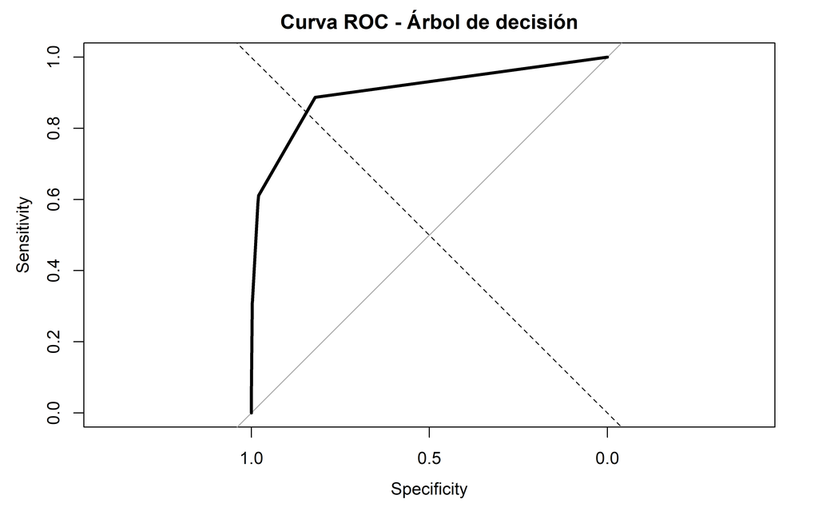

```r
plot(
  roc_cart,
  lwd = 3,
  main = "Curva ROC - Árbol de decisión"
)

abline(
  a = 0,
  b = 1,
  lty = 2
)
```

### 7.1.3 Área bajo la curva ROC

```r
auc_cart <- as.numeric(
  pROC::auc(roc_cart)
)

auc_cart
```

```
## [1] 0.9022937
```

**Interpretación**

El árbol de decisión obtuvo un valor de **ROC-AUC de 0.9022**. Este indicador representa la capacidad general del modelo para asignar una probabilidad mayor a un beneficiario con TEA que a uno sin TEA.

Un valor cercano a **0,50** indicaría una capacidad discriminante similar al azar, mientras que valores próximos a **1,00** representarían una separación casi perfecta entre ambas clases.

Sin embargo, debido al fuerte desbalance de la variable objetivo, la curva ROC debe analizarse junto con la sensibilidad y la curva Precision-Recall. Aunque el modelo puede presentar una capacidad global aceptable para ordenar los casos, la sensibilidad obtenida anteriormente muestra que, utilizando el punto de corte predeterminado, solamente identifica una pequeña proporción de los beneficiarios con TEA.

### 7.1.4 Curva Precision-Recall

Debido a que los casos positivos de TEA representan únicamente una pequeña proporción de la población, también se emplea la curva Precision-Recall. Esta métrica resulta especialmente útil en problemas de clasificación desbalanceados, ya que concentra la evaluación en el desempeño del modelo sobre la clase positiva.

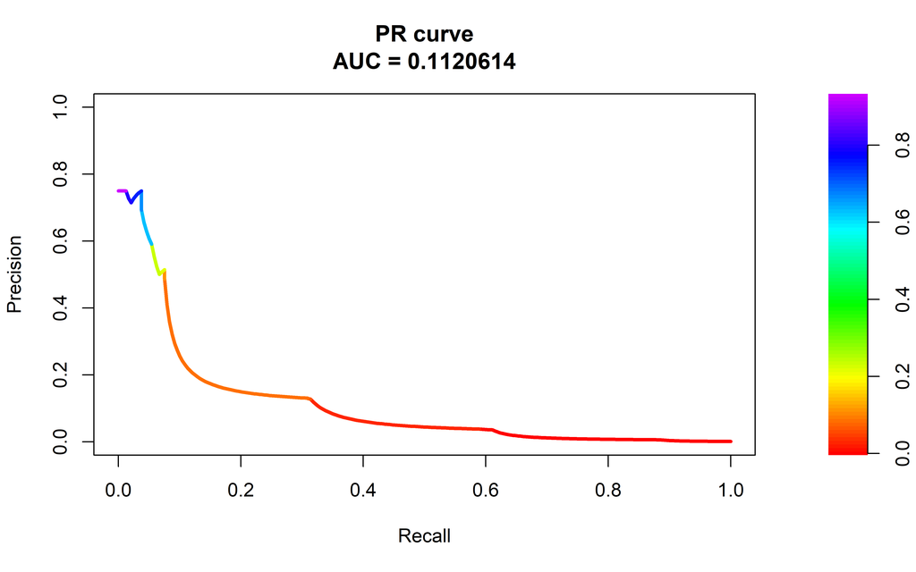

```r
pr_cart <- PRROC::pr.curve(
  scores.class0 = prob_cart$TEA[test$TEA == "TEA"],
  scores.class1 = prob_cart$TEA[test$TEA == "NoTEA"],
  curve = TRUE
)

plot(pr_cart)
```

```r
pr_auc_cart <- pr_cart$auc.integral

pr_auc_cart
```

```
## [1] 0.1120614
```

**Interpretación**

La curva Precision-Recall obtuvo un **PR-AUC de 0,1121**. Aunque este valor puede parecer reducido, debe interpretarse considerando el fuerte desbalance de la variable respuesta, ya que los beneficiarios con diagnóstico de TEA representan únicamente una fracción muy pequeña de la población analizada.

La curva Precision-Recall resulta especialmente útil en este contexto porque concentra la evaluación sobre la clase positiva. El resultado obtenido confirma que el árbol de decisión presenta dificultades para recuperar un número importante de casos de TEA sin incrementar simultáneamente el número de falsos positivos.

En conjunto, las métricas obtenidas muestran que el árbol constituye un modelo base adecuado para iniciar la comparación, aunque será necesario evaluar algoritmos más robustos que permitan mejorar la detección de beneficiarios con TEA sin sacrificar significativamente la precisión.

### 7.1.5 Función para evaluar los modelos

Con el fin de garantizar que todos los algoritmos sean evaluados bajo el mismo procedimiento, se construye una función que recibe las clases predichas, las probabilidades estimadas y los valores reales del conjunto de prueba.

La función calcula la exactitud, sensibilidad, especificidad, precisión, ROC-AUC y PR-AUC. De esta manera, se evita repetir el mismo código para cada modelo y se facilita la comparación final de resultados.

```r
evaluar_modelo <- function(nombre_modelo, prediccion, probabilidad, realidad) {

  matriz <- confusionMatrix(
    prediccion,
    realidad,
    positive = "TEA"
  )

  curva_roc <- pROC::roc(
    response = realidad,
    predictor = probabilidad,
    levels = c("NoTEA", "TEA"),
    direction = "<",
    quiet = TRUE
  )

  curva_pr <- PRROC::pr.curve(
    scores.class0 = probabilidad[realidad == "TEA"],
    scores.class1 = probabilidad[realidad == "NoTEA"],
    curve = TRUE
  )

  tibble(
    Modelo = nombre_modelo,
    Accuracy = as.numeric(matriz$overall["Accuracy"]),
    Sensibilidad = as.numeric(matriz$byClass["Sensitivity"]),
    Especificidad = as.numeric(matriz$byClass["Specificity"]),
    Precision = as.numeric(matriz$byClass["Pos Pred Value"]),
    ROC_AUC = as.numeric(pROC::auc(curva_roc)),
    PR_AUC = curva_pr$auc.integral
  )
}
```

### 7.1.6 Evaluación automática del árbol de decisión

Se aplica la función anterior a las predicciones y probabilidades obtenidas mediante el árbol de decisión.

```r
resultados_cart <- evaluar_modelo(
  nombre_modelo = "Árbol de decisión",
  prediccion = pred_cart,
  probabilidad = prob_cart$TEA,
  realidad = test$TEA
)

knitr::kable(
  resultados_cart,
  digits = 4,
  caption = "Resumen de las métricas del árbol de decisión."
)
```

Resumen de las métricas del árbol de decisión.

| Modelo | Accuracy | Sensibilidad | Especificidad | Precision | ROC_AUC | PR_AUC |
| --- | --- | --- | --- | --- | --- | --- |
| Árbol de decisión | 0.9988 | 0.0544 | 1 | 0.5909 | 0.9023 | 0.1121 |

La tabla anterior reúne las principales métricas ya interpretadas para el árbol de decisión. Este objeto se conservará y posteriormente se combinará con los resultados obtenidos mediante los demás algoritmos.

```r
resultados_modelos <- resultados_cart
```

### 7.1.7 Guardado del árbol de decisión

Debido al costo computacional asociado con el entrenamiento de los modelos, se guarda el árbol de decisión ya ajustado. De esta manera, podrá recuperarse posteriormente sin necesidad de entrenarlo nuevamente.

```r
saveRDS(
  modelo_cart,
  "modelo_cart.rds"
)
```

## 7.2 Random Forest

El segundo algoritmo corresponde a **Random Forest**, un método de ensamble que construye múltiples árboles de decisión utilizando muestras bootstrap y subconjuntos aleatorios de variables. La predicción final se obtiene mediante la votación conjunta de todos los árboles.

En comparación con un árbol individual, Random Forest suele presentar mayor estabilidad y capacidad predictiva, aunque reduce la facilidad de interpretación directa.

```r
library(randomForest)
```

Por el tamaño de la base y para evitar un bloqueo de R, comenzaremos con 200 árboles y sin validación cruzada adicional, utilizando directamente el conjunto de entrenamiento ya definido.

```r
set.seed(123)

modelo_rf <- randomForest(
  TEA ~ .,
  data = train,
  ntree = 200,
  importance = TRUE
)
```

Guardamos

```r
saveRDS(
  modelo_rf,
  "modelo_rf.rds"
)
```

### 7.2.1 Predicciones de Random Forest

```r
pred_rf <- predict(
  modelo_rf,
  newdata = test,
  type = "response"
)
```

```r
prob_rf <- predict(
  modelo_rf,
  newdata = test,
  type = "prob"
)[, "TEA"]
```

### 7.2.2 Evaluación de Random Forest

```r
resultados_rf <- evaluar_modelo(
  nombre_modelo = "Random Forest",
  prediccion = pred_rf,
  probabilidad = prob_rf,
  realidad = test$TEA
)

knitr::kable(
  resultados_rf,
  digits = 4,
  caption = "Métricas de desempeño de Random Forest."
)
```

Métricas de desempeño de Random Forest.

| Modelo | Accuracy | Sensibilidad | Especificidad | Precision | ROC_AUC | PR_AUC |
| --- | --- | --- | --- | --- | --- | --- |
| Random Forest | 0.9988 | 0.0544 | 1 | 0.7222 | 0.9493 | 0.3334 |

```r
resultados_modelos <- bind_rows(
  resultados_modelos,
  resultados_rf
)
```

```r
knitr::kable(
  resultados_modelos,
  digits = 4,
  caption = "Comparación parcial de los modelos."
)
```

Comparación parcial de los modelos.

| Modelo | Accuracy | Sensibilidad | Especificidad | Precision | ROC_AUC | PR_AUC |
| --- | --- | --- | --- | --- | --- | --- |
| Árbol de decisión | 0.9988 | 0.0544 | 1 | 0.5909 | 0.9023 | 0.1121 |
| Random Forest | 0.9988 | 0.0544 | 1 | 0.7222 | 0.9493 | 0.3334 |

**Interpretación**

Random Forest obtuvo una **exactitud (Accuracy) de 99,88 %**, valor prácticamente idéntico al observado para el árbol de decisión. Asimismo, la sensibilidad (**5,44 %**) y la especificidad (**100 %**) permanecieron sin cambios, indicando que ambos modelos presentan un comportamiento similar cuando se utiliza el punto de corte de clasificación predeterminado.

Sin embargo, se observan mejoras importantes en las métricas basadas en probabilidades. La **precisión aumentó de 59,09 % a 72,22 %**, indicando que las predicciones positivas realizadas por Random Forest presentan una mayor proporción de verdaderos casos de TEA.

De igual manera, el **ROC-AUC aumentó de 0,9023 a 0,9493**, evidenciando una mejor capacidad del modelo para discriminar entre beneficiarios con y sin diagnóstico de TEA. La mejora más notable se observa en la **curva Precision-Recall**, cuyo valor pasó de **0,1121** en el árbol de decisión a **0,3334** en Random Forest. Dado el fuerte desbalance presente en la base de datos, esta métrica resulta especialmente relevante y su incremento sugiere que Random Forest ofrece un desempeño considerablemente superior para priorizar correctamente los casos positivos.

En conjunto, estos resultados muestran que Random Forest constituye una alternativa más robusta que el árbol de decisión, especialmente cuando el interés principal radica en identificar beneficiarios con TEA dentro de una población donde la clase positiva es poco frecuente.

## 7.3 XGBoost

El tercer algoritmo evaluado corresponde a **Extreme Gradient Boosting (XGBoost)**, una técnica de ensamble basada en Gradient Boosting que construye árboles de decisión de manera secuencial. Cada nuevo árbol busca corregir los errores cometidos por los árboles previamente construidos, permitiendo obtener modelos con elevada capacidad predictiva.

XGBoost incorpora además mecanismos de regularización que reducen el sobreajuste y optimizaciones computacionales que lo convierten en uno de los algoritmos más utilizados en problemas de clasificación con datos estructurados.

```r
library(xgboost)
```

### 7.3.1 Preparación de las matrices para XGBoost

XGBoost requiere que todas las variables predictoras sean numéricas. Por esta razón, las variables categóricas se transforman en variables indicadoras mediante codificación *dummy*.

El codificador se ajusta exclusivamente con el conjunto de entrenamiento y posteriormente se aplica al conjunto de prueba. Esto garantiza que ambas matrices contengan exactamente las mismas variables y evita utilizar información del conjunto de prueba durante la preparación del modelo.

Primero convertimos la variable respuesta a formato numérico (0/1), como lo requiere `xgboost`, y ajustamos el codificador *dummy* únicamente con el conjunto de entrenamiento.

```r
train_xgb <- train %>%
  mutate(
    TEA = if_else(TEA == "TEA", 1, 0)
  )

test_xgb <- test %>%
  mutate(
    TEA = if_else(TEA == "TEA", 1, 0)
  )
```

```r
codificador_dummy <- dummyVars(
  TEA ~ .,
  data = train_xgb,
  fullRank = TRUE
)

x_train <- predict(
  codificador_dummy,
  newdata = train_xgb
)

x_test <- predict(
  codificador_dummy,
  newdata = test_xgb
)
```

Verificamos que ambas matrices tengan las mismas columnas antes de continuar. En caso de que alguna categoría poco frecuente solo aparezca en uno de los dos conjuntos, se homogenizan las columnas a continuación.

```r
columnas_faltantes <- setdiff(
  colnames(x_train),
  colnames(x_test)
)

columnas_adicionales <- setdiff(
  colnames(x_test),
  colnames(x_train)
)

columnas_faltantes
```

```
## [1] "tipo_beneficiarioMAE"      "tipo_beneficiarioTUTELADO"
```

```r
columnas_adicionales
```

```
## character(0)
```

```r
if (length(columnas_faltantes) > 0) {

  columnas_cero <- matrix(
    0,
    nrow = nrow(x_test),
    ncol = length(columnas_faltantes),
    dimnames = list(NULL, columnas_faltantes)
  )

  x_test <- cbind(
    x_test,
    columnas_cero
  )
}
```

```r
if (length(columnas_adicionales) > 0) {

  x_test <- x_test[
    ,
    !colnames(x_test) %in% columnas_adicionales,
    drop = FALSE
  ]
}
```

```r
x_test <- x_test[
  ,
  colnames(x_train),
  drop = FALSE
]

storage.mode(x_train) <- "double"
storage.mode(x_test) <- "double"
```

```r
dim(x_train)
```

```
## [1] 455112     20
```

```r
dim(x_test)
```

```
## [1] 195048     20
```

```r
identical(
  colnames(x_train),
  colnames(x_test)
)
```

```
## [1] TRUE
```

Entrenamos, nuevamente, XGBoost

```r
set.seed(123)

modelo_xgb <- xgboost(
  data = x_train,
  label = train_xgb$TEA,
  objective = "binary:logistic",
  nrounds = 100,
  max_depth = 4,
  eta = 0.10,
  verbose = 0
)
```

```r
saveRDS(
  modelo_xgb,
  "modelo_xgb.rds"
)
```

Generamos las predicciones

```r
prob_xgb <- predict(
  modelo_xgb,
  newdata = x_test
)
```

```r
pred_xgb <- factor(
  ifelse(
    prob_xgb >= 0.5,
    "TEA",
    "NoTEA"
  ),
  levels = c("NoTEA", "TEA")
)
```

### 7.3.2 Evaluación de XGBoost

```r
resultados_xgb <- evaluar_modelo(
  nombre_modelo = "XGBoost",
  prediccion = pred_xgb,
  probabilidad = prob_xgb,
  realidad = test$TEA
)

knitr::kable(
  resultados_xgb,
  digits = 4,
  caption = "Métricas de desempeño de XGBoost."
)
```

Métricas de desempeño de XGBoost.

| Modelo | Accuracy | Sensibilidad | Especificidad | Precision | ROC_AUC | PR_AUC |
| --- | --- | --- | --- | --- | --- | --- |
| XGBoost | 0.9988 | 0.0126 | 1 | 0.75 | 0.9872 | 0.2314 |

```r
resultados_modelos <- bind_rows(
  resultados_modelos,
  resultados_xgb
)
```

```r
knitr::kable(
  resultados_modelos,
  digits = 4,
  caption = "Comparación parcial de los modelos evaluados."
)
```

Comparación parcial de los modelos evaluados.

| Modelo | Accuracy | Sensibilidad | Especificidad | Precision | ROC_AUC | PR_AUC |
| --- | --- | --- | --- | --- | --- | --- |
| Árbol de decisión | 0.9988 | 0.0544 | 1 | 0.5909 | 0.9023 | 0.1121 |
| Random Forest | 0.9988 | 0.0544 | 1 | 0.7222 | 0.9493 | 0.3334 |
| XGBoost | 0.9988 | 0.0126 | 1 | 0.7500 | 0.9872 | 0.2314 |

### 7.3.3 Importancia de las variables en XGBoost

La importancia de variables permite identificar cuáles predictores contribuyeron en mayor medida a las decisiones del modelo. En XGBoost, la métrica `Gain` representa la mejora promedio obtenida al utilizar una variable para realizar divisiones dentro de los árboles.

```r
importancia_xgb <- xgb.importance(
  feature_names = colnames(x_train),
  model = modelo_xgb
)

knitr::kable(
  head(importancia_xgb, 10),
  digits = 4,
  caption = "Diez variables más importantes en XGBoost."
)
```

Diez variables más importantes en XGBoost.

| Feature | Gain | Cover | Frequency |
| --- | --- | --- | --- |
| edad | 0.3383 | 0.6818 | 0.1771 |
| costo_total | 0.2673 | 0.1777 | 0.1948 |
| costo_maximo | 0.1307 | 0.0302 | 0.2013 |
| costo_promedio | 0.1028 | 0.0431 | 0.1445 |
| especialidades_distintas | 0.0589 | 0.0104 | 0.0475 |
| numero_utilizaciones | 0.0559 | 0.0429 | 0.1575 |
| tipo_beneficiarioTITULAR | 0.0295 | 0.0089 | 0.0345 |
| procedimientos_distintos | 0.0099 | 0.0029 | 0.0242 |
| sexoM | 0.0040 | 0.0011 | 0.0056 |
| hospitalizaciones | 0.0018 | 0.0007 | 0.0037 |

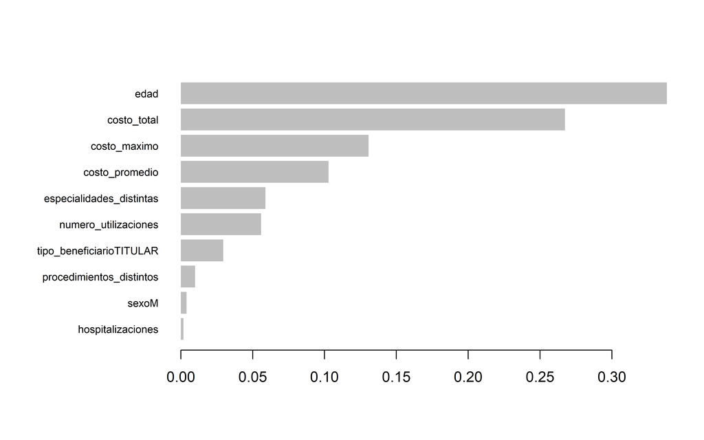

```r
xgb.plot.importance(
  importancia_xgb,
  top_n = 10
)
```

**Interpretación**

Las variables con mayor valor de `Gain` fueron las que más contribuyeron a mejorar la clasificación realizada por XGBoost. Su importancia permitirá comparar posteriormente si los predictores más relevantes coinciden con los identificados por el árbol de decisión y Random Forest.

### 7.3.4 Guardado del modelo XGBoost

```r
saveRDS(
  modelo_xgb,
  "modelo_xgb.rds"
)
```

### 7.3.5 Interpretación del análisis supervisado

Los tres modelos evaluados presentan una **exactitud cercana al 99,88 %** y una **especificidad del 100 %**, resultado esperable debido al fuerte desbalance existente entre beneficiarios con y sin diagnóstico de TEA. Por esta razón, la comparación entre algoritmos debe centrarse principalmente en métricas como la sensibilidad, la precisión, el ROC-AUC y el PR-AUC.

El **árbol de decisión** constituye el modelo más sencillo e interpretable, aunque obtuvo el menor desempeño probabilístico, con un **ROC-AUC de 0,9023** y un **PR-AUC de 0,1121**.

Por su parte, **Random Forest** mejoró considerablemente la capacidad discriminante del modelo, alcanzando un **ROC-AUC de 0,9493** y el mayor **PR-AUC (0,3334)** entre los algoritmos evaluados hasta el momento. Este resultado sugiere que Random Forest ofrece el mejor equilibrio para identificar correctamente beneficiarios con TEA en un escenario altamente desbalanceado.

Finalmente, **XGBoost** obtuvo el **mayor ROC-AUC (0,9872)** y la mayor precisión (**75,00 %**), indicando una excelente capacidad para ordenar los beneficiarios según su probabilidad de presentar TEA. Sin embargo, esta mejora estuvo acompañada de una disminución en la sensibilidad (**1,26 %**), lo que evidencia que el modelo adopta una estrategia más conservadora al clasificar casos positivos utilizando el punto de corte predeterminado.

En conjunto, estos resultados muestran que, aunque XGBoost presenta la mayor capacidad discriminante global, Random Forest logra un mejor compromiso entre la identificación de casos positivos y la precisión de las predicciones, aspecto especialmente relevante en problemas con clases altamente desbalanceadas.

# 8. Análisis no supervisado

El aprendizaje supervisado permitió construir modelos predictivos para identificar beneficiarios con Trastorno del Espectro Autista a partir de variables previamente definidas. Sin embargo, la minería de datos también busca descubrir estructuras y patrones presentes en la información sin utilizar una variable objetivo.

En esta sección se emplearán técnicas de aprendizaje no supervisado con el propósito de explorar agrupamientos naturales entre los beneficiarios y detectar posibles observaciones atípicas que puedan representar comportamientos inusuales en la utilización de los servicios de salud.

## 8.1 Escalamiento de las variables

Los modelos basados en distancias o en penalizaciones son sensibles a la escala de las variables. Por ejemplo, una variable como `costo_total` puede tomar valores mucho mayores que `edad` o `numero_utilizaciones`, lo que podría hacer que domine artificialmente el cálculo de distancias o la estimación de los coeficientes.

Por esta razón, las variables numéricas serán estandarizadas mediante z-score, de manera que cada una tenga media cero y desviación estándar igual a uno. Los parámetros de escalamiento se estimarán exclusivamente con el conjunto de entrenamiento y posteriormente se aplicarán al conjunto de prueba, evitando así introducir información del conjunto de evaluación durante el entrenamiento.

```r
variables_numericas <- c(
  "edad",
  "numero_utilizaciones",
  "procedimientos_distintos",
  "especialidades_distintas",
  "hospitalizaciones",
  "ingresos_uti",
  "costo_total",
  "costo_promedio",
  "costo_maximo"
)
```

```r
preproceso <- preProcess(
  train[, variables_numericas],
  method = c("center", "scale")
)
```

```r
train_escalado <- train
test_escalado <- test

train_escalado[, variables_numericas] <- predict(
  preproceso,
  train[, variables_numericas]
)

test_escalado[, variables_numericas] <- predict(
  preproceso,
  test[, variables_numericas]
)
```

```r
summary(
  train_escalado[, variables_numericas]
)
```

```
##       edad         numero_utilizaciones procedimientos_distintos
##  Min.   :-1.7495   Min.   :-0.5266      Min.   :-0.6130
##  1st Qu.:-0.7553   1st Qu.:-0.5266      1st Qu.:-0.6130
##  Median : 0.0129   Median :-0.3116      Median :-0.4341
##  Mean   : 0.0000   Mean   : 0.0000      Mean   : 0.0000
##  3rd Qu.: 0.6907   3rd Qu.: 0.1185      3rd Qu.: 0.1027
##  Max.   : 3.1309   Max.   :22.9136      Max.   :12.6278
##  especialidades_distintas hospitalizaciones    ingresos_uti
##  Min.   :-0.3698          Min.   : -0.06666   Min.   : -0.03347
##  1st Qu.:-0.3698          1st Qu.: -0.06666   1st Qu.: -0.03347
##  Median :-0.3698          Median : -0.06666   Median : -0.03347
##  Mean   : 0.0000          Mean   :  0.00000   Mean   :  0.00000
##  3rd Qu.:-0.3698          3rd Qu.: -0.06666   3rd Qu.: -0.03347
##  Max.   :16.6614          Max.   :103.82014   Max.   :176.47482
##   costo_total        costo_promedio        costo_maximo
##  Min.   : -0.15390   Min.   : -0.155694   Min.   : -0.14458
##  1st Qu.: -0.13995   1st Qu.: -0.114600   1st Qu.: -0.11534
##  Median : -0.12085   Median : -0.065350   Median : -0.10479
##  Mean   :  0.00000   Mean   :  0.000000   Mean   :  0.00000
##  3rd Qu.: -0.07381   3rd Qu.: -0.009569   3rd Qu.: -0.07612
##  Max.   :191.51273   Max.   :297.794162   Max.   :183.60264
```

**Interpretación**

Después del escalamiento, las variables numéricas del conjunto de entrenamiento quedaron expresadas en una escala comparable, con valores centrados alrededor de cero. Esta transformación será utilizada en los modelos sensibles a la magnitud de las variables, como KNN, SVM y regresión logística penalizada.

### 8.1.1 Guardado de la base escalada

```r
saveRDS(
  train_escalado,
  "train_escalado.rds"
)

saveRDS(
  test_escalado,
  "test_escalado.rds"
)
```

## 8.2 Support Vector Machine (SVM)

El siguiente algoritmo evaluado corresponde a las **Máquinas de Soporte Vectorial (Support Vector Machine, SVM)**. Este método busca encontrar un hiperplano que maximice la separación entre las clases, utilizando únicamente aquellas observaciones más cercanas a la frontera de decisión, conocidas como **vectores de soporte**.

Las SVM son especialmente útiles cuando existen relaciones complejas entre las variables predictoras y la variable respuesta. Debido a que el algoritmo depende de distancias entre observaciones, es indispensable utilizar las variables previamente estandarizadas.

```r
library(purrr)
library(kernlab)
```

### 8.2.1 Ajuste computacional para SVM

El entrenamiento inicial de SVM sobre la totalidad del conjunto de entrenamiento no fue computacionalmente viable. La implementación utilizada intentó reservar una cantidad de memoria cercana a 985 GB, debido al elevado número de observaciones y al costo computacional del algoritmo.

Para hacer posible su aplicación, se construyó una muestra de entrenamiento que conserva todos los beneficiarios con TEA y selecciona aleatoriamente diez beneficiarios sin TEA por cada caso positivo. Esta estrategia reduce considerablemente el tamaño de los datos utilizados para ajustar el modelo, mientras que la evaluación continúa realizándose sobre el conjunto de prueba completo y sin modificar.

Construcción de la muestra para SVM

```r
set.seed(123)

train_svm_tea <- train_escalado %>%
  filter(TEA == "TEA")

n_tea_svm <- nrow(train_svm_tea)

train_svm_no_tea <- train_escalado %>%
  filter(TEA == "NoTEA") %>%
  slice_sample(
    n = min(
      nrow(.),
      10 * n_tea_svm
    )
  )

train_svm <- bind_rows(
  train_svm_tea,
  train_svm_no_tea
) %>%
  slice_sample(prop = 1)
```

verificamos la muestra

```r
dim(train_svm)
```

```
## [1] 6270   12
```

```r
table(train_svm$TEA)
```

```
##
## NoTEA   TEA
##  5700   570
```

```r
prop.table(
  table(train_svm$TEA)
)
```

```
##
##      NoTEA        TEA
## 0.90909091 0.09090909
```

**Interpretación**

La muestra utilizada para entrenar SVM conserva la totalidad de los casos positivos disponibles en el conjunto de entrenamiento e incorpora diez observaciones negativas por cada beneficiario con TEA. Esta reducción se aplica únicamente durante el ajuste del modelo; el desempeño será evaluado sobre el conjunto de prueba completo, que mantiene la prevalencia original de la condición.

**Entrenamiento de SVM lineal**

En lugar de caret::train(), usaremos directamente e1071::svm(), evitando la validación cruzada de cinco particiones que multiplicaba aún más el costo computacional.

```r
set.seed(123)

modelo_svm <- e1071::svm(
  TEA ~ .,
  data = train_svm,
  kernel = "linear",
  cost = 1,
  probability = TRUE,
  scale = FALSE
)
```

Guardado del modelo

```r
saveRDS(
  modelo_svm,
  "modelo_svm.rds"
)
```

Predicciones sobre el test completo

```r
pred_svm <- predict(
  modelo_svm,
  newdata = test_escalado,
  probability = TRUE
)
```

Extracción de probabilidades

```r
probabilidades_svm <- attr(
  pred_svm,
  "probabilities"
)

colnames(probabilidades_svm)
```

```
## [1] "NoTEA" "TEA"
```

Probabilidad de TEA

```r
prob_svm <- probabilidades_svm[, "TEA"]
```

Aseguramos el orden de los niveles:

```r
pred_svm <- factor(
  pred_svm,
  levels = c("NoTEA", "TEA")
)
```

Evaluación del modelo

```r
resultados_svm <- evaluar_modelo(
  nombre_modelo = "SVM lineal",
  prediccion = pred_svm,
  probabilidad = prob_svm,
  realidad = test_escalado$TEA
)

knitr::kable(
  resultados_svm,
  digits = 4,
  caption = "Métricas de desempeño de SVM lineal."
)
```

Métricas de desempeño de SVM lineal.

| Modelo | Accuracy | Sensibilidad | Especificidad | Precision | ROC_AUC | PR_AUC |
| --- | --- | --- | --- | --- | --- | --- |
| SVM lineal | 0.9827 | 0.5314 | 0.9832 | 0.0374 | 0.9569 | 0.0273 |

**Incorporación a la comparación**

```r
resultados_modelos <- bind_rows(
  resultados_modelos,
  resultados_svm
)

knitr::kable(
  resultados_modelos,
  digits = 4,
  caption = "Comparación parcial de los modelos evaluados."
)
```

Comparación parcial de los modelos evaluados.

| Modelo | Accuracy | Sensibilidad | Especificidad | Precision | ROC_AUC | PR_AUC |
| --- | --- | --- | --- | --- | --- | --- |
| Árbol de decisión | 0.9988 | 0.0544 | 1.0000 | 0.5909 | 0.9023 | 0.1121 |
| Random Forest | 0.9988 | 0.0544 | 1.0000 | 0.7222 | 0.9493 | 0.3334 |
| XGBoost | 0.9988 | 0.0126 | 1.0000 | 0.7500 | 0.9872 | 0.2314 |
| SVM lineal | 0.9827 | 0.5314 | 0.9832 | 0.0374 | 0.9569 | 0.0273 |

**Interpretación**

El modelo **SVM lineal** obtuvo una **exactitud del 98,27 %**, ligeramente inferior a la observada en los modelos basados en árboles. Sin embargo, presentó una **sensibilidad del 53,14 %**, la más alta entre los algoritmos evaluados hasta el momento, lo que indica una mayor capacidad para identificar correctamente beneficiarios con diagnóstico de TEA.

Esta mejora en la sensibilidad estuvo acompañada de una disminución en la **precisión (3,74 %)**, evidenciando que el modelo clasificó un mayor número de beneficiarios como positivos, incrementando también la cantidad de falsos positivos. Este comportamiento es común en problemas con un fuerte desbalance entre clases, donde aumentar la detección de la clase minoritaria suele implicar una reducción en la precisión.

Adicionalmente, el modelo alcanzó un **ROC-AUC de 0,9569**, confirmando una buena capacidad discriminante entre ambas clases. No obstante, el **PR-AUC (0,0273)** fue considerablemente inferior al obtenido por Random Forest y XGBoost, indicando que el desempeño específico sobre la clase minoritaria aún es limitado.

En conjunto, el SVM lineal representa el modelo con mayor capacidad para detectar casos positivos de TEA entre los algoritmos evaluados hasta el momento, aunque dicha mejora se logra a costa de un incremento importante en la proporción de falsos positivos.

## 8.3 K-Nearest Neighbors (KNN)

El algoritmo **K-Nearest Neighbors (KNN)** clasifica cada observación de acuerdo con la categoría predominante entre sus vecinos más cercanos. Debido a que este método utiliza distancias entre observaciones, resulta indispensable trabajar con variables previamente estandarizadas.

```r
library(kknn)
```

```r
set.seed(123)

modelo_knn <- train(

  TEA ~ .,

  data = train_svm,

  method = "kknn",

  tuneLength = 10,

  metric = "ROC",

  trControl = control

)
```

```r
saveRDS(
  modelo_knn,
  "modelo_knn.rds"
)
```

**Predicciones**

```r
pred_knn <- predict(
  modelo_knn,
  newdata = test_escalado
)
```

```r
prob_knn <- predict(
  modelo_knn,
  newdata = test_escalado,
  type = "prob"
)
```

**Evaluacion**

```r
resultados_knn <- evaluar_modelo(

  nombre_modelo = "KNN",

  prediccion = pred_knn,

  probabilidad = prob_knn$TEA,

  realidad = test_escalado$TEA

)

knitr::kable(
  resultados_knn,
  digits = 4,
  caption = "Métricas de desempeño de KNN."
)
```

Métricas de desempeño de KNN.

| Modelo | Accuracy | Sensibilidad | Especificidad | Precision | ROC_AUC | PR_AUC |
| --- | --- | --- | --- | --- | --- | --- |
| KNN | 0.9764 | 0.7741 | 0.9766 | 0.0391 | 0.9662 | 0.0796 |

**Interpretación**

El modelo **K-Nearest Neighbors (KNN)** obtuvo una **exactitud del 97,64 %**, inferior a la alcanzada por los modelos basados en árboles y por SVM. Sin embargo, presentó la **mayor sensibilidad (77,41 %)** entre todos los algoritmos evaluados hasta el momento, lo que indica una elevada capacidad para identificar correctamente beneficiarios con diagnóstico de TEA.

Este incremento en la sensibilidad estuvo acompañado de una reducción en la **precisión (3,91 %)**, reflejando un mayor número de falsos positivos. Este comportamiento es característico de los algoritmos basados en vecinos, los cuales tienden a favorecer la detección de la clase minoritaria cuando las variables han sido adecuadamente estandarizadas.

Adicionalmente, KNN alcanzó un **ROC-AUC de 0,9662**, valor que evidencia una buena capacidad discriminante entre ambas clases. No obstante, el **PR-AUC (0,0796)** continúa siendo inferior al obtenido por Random Forest y XGBoost, lo que sugiere que, aunque el modelo identifica una mayor proporción de casos positivos, mantiene limitaciones para lograr una alta precisión sobre la clase minoritaria.

En conjunto, KNN constituye el algoritmo con mejor capacidad de detección de beneficiarios con TEA entre los modelos evaluados hasta el momento. Sin embargo, esta ventaja implica un incremento considerable en la cantidad de falsos positivos, por lo que su utilización dependerá del equilibrio deseado entre sensibilidad y precisión.

**Actualizamos la comparación**

```r
resultados_modelos <- bind_rows(
  resultados_modelos,
  resultados_knn
)

knitr::kable(
  resultados_modelos,
  digits = 4,
  caption = "Comparación parcial de los modelos."
)
```

Comparación parcial de los modelos.

| Modelo | Accuracy | Sensibilidad | Especificidad | Precision | ROC_AUC | PR_AUC |
| --- | --- | --- | --- | --- | --- | --- |
| Árbol de decisión | 0.9988 | 0.0544 | 1.0000 | 0.5909 | 0.9023 | 0.1121 |
| Random Forest | 0.9988 | 0.0544 | 1.0000 | 0.7222 | 0.9493 | 0.3334 |
| XGBoost | 0.9988 | 0.0126 | 1.0000 | 0.7500 | 0.9872 | 0.2314 |
| SVM lineal | 0.9827 | 0.5314 | 0.9832 | 0.0374 | 0.9569 | 0.0273 |
| KNN | 0.9764 | 0.7741 | 0.9766 | 0.0391 | 0.9662 | 0.0796 |

## 8.4 Agrupamiento mediante K-means

El algoritmo **K-means** es una técnica de aprendizaje no supervisado cuyo objetivo consiste en agrupar observaciones similares sin utilizar la variable respuesta. El algoritmo asigna cada beneficiario al grupo cuyo centroide se encuentra más próximo, minimizando la variabilidad dentro de cada clúster y maximizando la separación entre grupos.

Dado el tamaño de la base de datos, el agrupamiento se realiza sobre una muestra aleatoria de beneficiarios previamente estandarizada. Esta estrategia reduce el tiempo de procesamiento sin afectar la identificación de los principales patrones presentes en la información.

Construccion de la muestra

**Justificación de la muestra**

Aunque la base analítica contiene más de 650.000 beneficiarios, la determinación del número óptimo de clústeres mediante los métodos del codo y de la silueta implica ejecutar el algoritmo K-means múltiples veces, lo que incrementa considerablemente el costo computacional. Por esta razón, se empleó una muestra aleatoria de 10.000 beneficiarios, suficiente para identificar la estructura general de los datos y reducir el tiempo de procesamiento.

```r
set.seed(123)

muestra_cluster <- train_escalado %>%
  slice_sample(
    n = 10000
  )
```

Verificamos la dimension

```r
dim(muestra_cluster)
```

```
## [1] 10000    12
```

```r
datos_cluster <- muestra_cluster %>%
  select(-TEA)
```

```r
summary(datos_cluster)
```

```
##       edad              sexo           tipo_beneficiario  numero_utilizaciones
##  Min.   :-1.74946   Length:10000       Length:10000       Min.   :-0.5266213
##  1st Qu.:-0.75531   Class :character   Class :character   1st Qu.:-0.5266213
##  Median : 0.01290   Mode  :character   Mode  :character   Median :-0.3115733
##  Mean   :-0.00587                                         Mean   :-0.0002697
##  3rd Qu.: 0.64554                                         3rd Qu.: 0.1185228
##  Max.   : 2.90498                                         Max.   :17.7524602
##  procedimientos_distintos especialidades_distintas hospitalizaciones
##  Min.   :-0.612991        Min.   :-0.3698          Min.   :-0.066658
##  1st Qu.:-0.612991        1st Qu.:-0.3698          1st Qu.:-0.066658
##  Median :-0.434062        Median :-0.3698          Median :-0.066658
##  Mean   : 0.003654        Mean   :-0.0139          Mean   :-0.005365
##  3rd Qu.: 0.102728        3rd Qu.:-0.3698          3rd Qu.:-0.066658
##  Max.   : 8.154566        Max.   :10.6504          Max.   :41.488060
##   ingresos_uti         costo_total        costo_promedio
##  Min.   : -0.033466   Min.   :-0.153901   Min.   :-0.155694
##  1st Qu.: -0.033466   1st Qu.:-0.139953   1st Qu.:-0.115052
##  Median : -0.033466   Median :-0.121719   Median :-0.066835
##  Mean   :  0.008742   Mean   :-0.001168   Mean   :-0.010899
##  3rd Qu.: -0.033466   3rd Qu.:-0.074478   3rd Qu.:-0.009569
##  Max.   :109.964452   Max.   :70.321273   Max.   :13.793146
##   costo_maximo
##  Min.   :-0.144579
##  1st Qu.:-0.115338
##  Median :-0.104665
##  Mean   :-0.004959
##  3rd Qu.:-0.076120
##  Max.   :28.263066
```

```r
saveRDS(
  datos_cluster,
  "datos_cluster.rds"
)
```

### 8.4.1 Determinación de número óptimo de grupos

```r
library(factoextra)
library(cluster)
```

```r
glimpse(datos_cluster)
```

```
## Rows: 10,000
## Columns: 11
## $ edad                     <dbl> -0.48417492, -1.47832765, -0.48417492, 2.0915…
## $ sexo                     <chr> "M", "M", "F", "M", "F", "F", "F", "M", "F", …
## $ tipo_beneficiario        <chr> "DEPENDENTE", "DEPENDENTE", "TITULAR", "TITUL…
## $ numero_utilizaciones     <dbl> -0.52662127, -0.52662127, -0.52662127, 0.9787…
## $ procedimientos_distintos <dbl> -0.6129914, -0.6129914, -0.6129914, 0.1921925…
## $ especialidades_distintas <dbl> -0.3697541, -0.3697541, -0.3697541, 3.6375690…
## $ hospitalizaciones        <dbl> -0.06665795, -0.06665795, -0.06665795, -0.066…
## $ ingresos_uti             <dbl> -0.03346621, -0.03346621, -0.03346621, -0.033…
## $ costo_total              <dbl> -0.139952884, -0.140042390, -0.143843883, 0.1…
## $ costo_promedio           <dbl> 0.013190357, 0.012106593, -0.033922934, -0.02…
## $ costo_maximo             <dbl> -0.10402426, -0.10428450, -0.11533760, 0.0466…
```

Como K-menas trabaja unicamente con variables númericas, vamos a retirar del análisis el sexo y el tipo de beneficiario

```r
datos_cluster <- muestra_cluster %>%
  select(
    edad,
    numero_utilizaciones,
    procedimientos_distintos,
    especialidades_distintas,
    hospitalizaciones,
    ingresos_uti,
    costo_total,
    costo_promedio,
    costo_maximo
  )
```

Revisamos usando tanto método del codo como método de la silueta

**Método del codo**

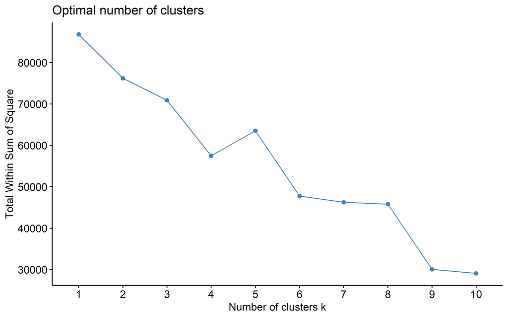

```r
fviz_nbclust(
  datos_cluster,
  kmeans,
  method = "wss"
)
```

**Método de la silueta**

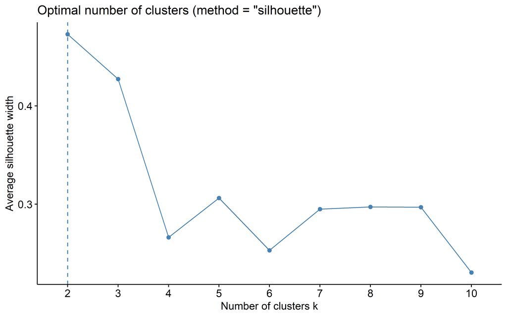

```r
fviz_nbclust(
  datos_cluster,
  kmeans,
  method = "silhouette"
)
```

**Interpretación**

El método del codo permite identificar el punto a partir del cual incrementar el número de clústeres produce una reducción marginal de la variabilidad interna. Por su parte, el índice de silueta evalúa simultáneamente la cohesión y separación entre grupos, proporcionando una medida de la calidad del agrupamiento.

La selección del número final de clústeres se realizará considerando conjuntamente ambos criterios.

Por otra parte, el método de la silueta presenta un máximo claramente identificado para $K = 2$, indicando que esta partición produce la mejor combinación entre cohesión interna y separación entre clústeres.

Considerando ambos resultados, se decidió utilizar **dos clústeres**, priorizando el criterio de la silueta debido a que proporciona una medida cuantitativa de la calidad del agrupamiento y presenta un máximo claramente definido.

### 8.4.2 Ajuste del algoritmo K-means

Con base en los resultados obtenidos mediante los métodos del codo y de la silueta, el algoritmo K-means se ajustó utilizando dos clústeres. Para reducir la probabilidad de converger a un óptimo local, el algoritmo se inicializó 25 veces con centroides aleatorios y se seleccionó la partición con menor variabilidad interna.

```r
set.seed(123)

modelo_kmeans <- kmeans(
  datos_cluster,
  centers = 2,
  nstart = 25,
  iter.max = 100
)
```

```r
tabla_clusters <- tibble(
  Cluster = modelo_kmeans$cluster
) %>%
  count(Cluster)

knitr::kable(
  tabla_clusters,
  caption = "Número de observaciones por clúster."
)
```

Número de observaciones por clúster.

| Cluster | n |
| --- | --- |
| 1 | 9974 |
| 2 | 26 |

```r
muestra_cluster <- muestra_cluster %>%
  mutate(
    Cluster = factor(
      modelo_kmeans$cluster
    )
  )
```

```r
perfil_clusters <- muestra_cluster %>%
  group_by(Cluster) %>%
  summarise(

    Edad_media = round(mean(edad), 2),

    Utilizaciones = round(mean(numero_utilizaciones), 2),

    Procedimientos = round(mean(procedimientos_distintos), 2),

    Especialidades = round(mean(especialidades_distintas), 2),

    Hospitalizaciones = round(mean(hospitalizaciones), 2),

    Ingresos_UTI = round(mean(ingresos_uti), 2),

    Costo_total = round(mean(costo_total), 2),

    Costo_promedio = round(mean(costo_promedio), 2),

    Costo_maximo = round(mean(costo_maximo), 2),

    .groups = "drop"

  )

knitr::kable(
  perfil_clusters,
  digits = 2,
  caption = "Perfil promedio de los clústeres identificados."
)
```

Perfil promedio de los clústeres identificados.

| Cluster | Edad_media | Utilizaciones | Procedimientos | Especialidades | Hospitalizaciones | Ingresos_UTI | Costo_total | Costo_promedio | Costo_maximo |
| --- | --- | --- | --- | --- | --- | --- | --- | --- | --- |
| 1 | -0.01 | -0.01 | 0.00 | -0.01 | -0.03 | -0.02 | -0.04 | -0.01 | -0.03 |
| 2 | 0.63 | 4.27 | 2.55 | -0.10 | 8.32 | 12.07 | 14.52 | 1.30 | 9.90 |

#### 8.4.2.1 Interpretación de los clústeres

La Tabla anterior resume el perfil promedio de los dos clústeres identificados mediante el algoritmo K-means. Debido a que las variables fueron previamente estandarizadas, los valores corresponden a desviaciones estándar respecto al promedio de toda la población. En consecuencia, valores cercanos a cero representan beneficiarios con un comportamiento promedio, mientras que valores positivos indican niveles superiores a la media y valores negativos niveles inferiores.

El **Clúster 1** concentra la mayoría de beneficiarios con un patrón de utilización cercano al promedio de la población. Las variables analizadas presentan valores próximos a cero, indicando un número habitual de utilizaciones, procedimientos, hospitalizaciones e ingresos a UTI, así como costos similares al comportamiento general del sistema de salud.

Por el contrario, el **Clúster 2** reúne beneficiarios con una utilización considerablemente más intensiva de los servicios de salud. Este grupo presenta un mayor número de utilizaciones, procedimientos realizados, hospitalizaciones e ingresos a unidades de cuidados intensivos. En consecuencia, también registra costos totales, costos promedio y costos máximos muy superiores al promedio de la población.

Estos resultados permiten concluir que el algoritmo K-means logró separar los beneficiarios en dos perfiles claramente diferenciados: un grupo de utilización habitual de los servicios de salud y un grupo de alta complejidad asistencial caracterizado por una mayor demanda de recursos y mayores costos médicos.

#### 8.4.2.2 Relación entre los clústeres y la presencia de TEA

```r
tabla_cluster_tea <- muestra_cluster %>%
  count(
    Cluster,
    TEA
  ) %>%
  group_by(Cluster) %>%
  mutate(
    Porcentaje = round(
      100 * n / sum(n),
      2
    )
  )

knitr::kable(
  tabla_cluster_tea,
  caption = "Distribución de TEA según el clúster."
)
```

Distribución de TEA según el clúster.

| Cluster | TEA | n | Porcentaje |
| --- | --- | --- | --- |
| 1 | NoTEA | 9962 | 99.88 |
| 1 | TEA | 12 | 0.12 |
| 2 | NoTEA | 26 | 100.00 |

#### 8.4.2.3 Interpretación de la relación entre los clústeres y la presencia de TEA

La distribución de la variable TEA muestra que prácticamente todos los beneficiarios, independientemente del clúster, corresponden a la categoría “No TEA”. En el Clúster 1 se identificaron únicamente 12 beneficiarios con TEA (0,12 %), mientras que el Clúster 2 no presentó ningún caso.

Este resultado debe interpretarse con extremo cuidado debido a que el segundo clúster está conformado por un número muy reducido de beneficiarios. En consecuencia, la ausencia de casos de TEA en dicho grupo no constituye evidencia suficiente para afirmar una asociación entre la pertenencia al clúster y la presencia del trastorno.

En conjunto, los resultados sugieren que el algoritmo K-means agrupó principalmente a los beneficiarios según su patrón de utilización de los servicios de salud y sus costos asociados, más que por la presencia o ausencia de TEA.

La identificación de un clúster muy pequeño y caracterizado por una utilización excepcionalmente alta de los servicios de salud motiva la aplicación de un algoritmo específico para la detección de anomalías. En la siguiente sección se emplea Isolation Forest con el objetivo de identificar observaciones atípicas de manera explícita y comparar sus resultados con los obtenidos mediante el agrupamiento.

## 8.5 Detección de anomalías mediante Isolation Forest

Aunque el algoritmo K-means permitió identificar dos perfiles de beneficiarios, uno de los clústeres estuvo conformado por un número muy reducido de observaciones caracterizadas por elevados niveles de utilización y costos. Este resultado sugiere la posible existencia de beneficiarios con comportamientos atípicos.

Con el fin de detectar explícitamente estas observaciones, se emplea el algoritmo **Isolation Forest**, una técnica de aprendizaje no supervisado diseñada para identificar anomalías. A diferencia de K-means, este algoritmo no busca formar grupos, sino aislar observaciones cuyo comportamiento difiere significativamente del resto de la población.

```r
library(solitude)
```

```r
set.seed(123)

modelo_if <- isolationForest$new(
  sample_size = 256,
  num_trees = 100,
  seed = 123
)

modelo_if$fit(datos_cluster)
```

**Obtención del puntaje de anomalia**

```r
anomalias <- modelo_if$predict(datos_cluster)
```

**Incorporación de los resultados**

```r
muestra_cluster <- muestra_cluster %>%
  mutate(
    score_anomalia = anomalias$anomaly_score
  )
```

**Resumen de los puntajes**

```r
summary(
  muestra_cluster$score_anomalia
)
```

```
##    Min. 1st Qu.  Median    Mean 3rd Qu.    Max.
##  0.5820  0.5820  0.5836  0.5908  0.5883  0.7983
```

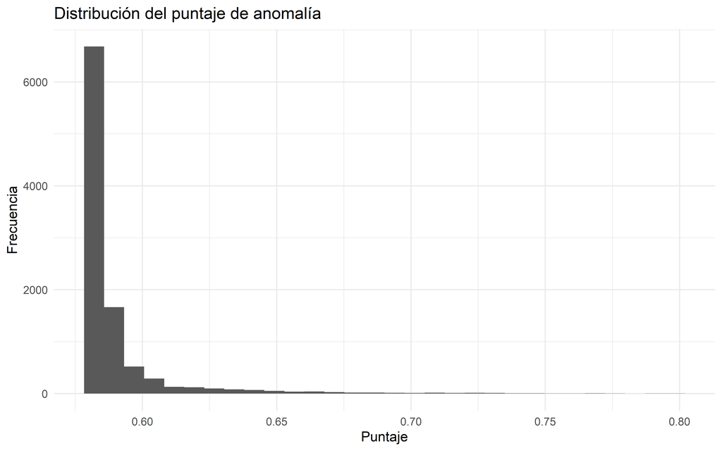

```r
ggplot(
  muestra_cluster,
  aes(
    x = score_anomalia
  )
) +
  geom_histogram(
    bins = 30
  ) +
  labs(
    title = "Distribución del puntaje de anomalía",
    x = "Puntaje",
    y = "Frecuencia"
  ) +
  theme_minimal()
```

**Selección de anomalías**

Hacemos una estrategia habitual, que consiste en tomar como anomalías el 1% de observaciones con mayor puntaje

```r
punto_corte <- quantile(
  muestra_cluster$score_anomalia,
  0.99
)

muestra_cluster <- muestra_cluster %>%
  mutate(
    Anomalia = ifelse(
      score_anomalia >= punto_corte,
      "Sí",
      "No"
    )
  )
```

**Número de anomalías**

```r
tabla_anomalias <- muestra_cluster %>%
  count(Anomalia) %>%
  mutate(
    Porcentaje = round(
      100 * n / sum(n),
      2
    )
  )

knitr::kable(
  tabla_anomalias,
  caption = "Distribución de anomalías detectadas."
)
```

Distribución de anomalías detectadas.

| Anomalia | n | Porcentaje |
| --- | --- | --- |
| No | 9900 | 99 |
| Sí | 100 | 1 |

**Perfil de las anomalías**

```r
perfil_anomalias <- muestra_cluster %>%
  group_by(Anomalia) %>%
  summarise(

    Edad_media = round(mean(edad),2),

    Utilizaciones = round(mean(numero_utilizaciones),2),

    Procedimientos = round(mean(procedimientos_distintos),2),

    Hospitalizaciones = round(mean(hospitalizaciones),2),

    Ingresos_UTI = round(mean(ingresos_uti),2),

    Costo_total = round(mean(costo_total),2),

    Costo_promedio = round(mean(costo_promedio),2),

    Costo_maximo = round(mean(costo_maximo),2),

    .groups = "drop"
  )

knitr::kable(
  perfil_anomalias,
  caption = "Perfil promedio de las anomalías detectadas."
)
```

Perfil promedio de las anomalías detectadas.

| Anomalia | Edad_media | Utilizaciones | Procedimientos | Hospitalizaciones | Ingresos_UTI | Costo_total | Costo_promedio | Costo_maximo |
| --- | --- | --- | --- | --- | --- | --- | --- | --- |
| No | -0.01 | -0.02 | -0.01 | -0.04 | -0.03 | -0.06 | -0.03 | -0.06 |
| Sí | 0.55 | 2.32 | 1.26 | 3.44 | 3.80 | 6.27 | 1.98 | 5.25 |

**Visualización**

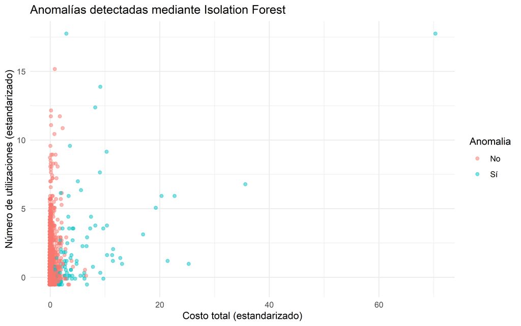

```r
ggplot(
  muestra_cluster,
  aes(
    x = costo_total,
    y = numero_utilizaciones,
    color = Anomalia
  )
) +
  geom_point(
    alpha = 0.5
  ) +
  labs(
    title = "Anomalías detectadas mediante Isolation Forest",
    x = "Costo total (estandarizado)",
    y = "Número de utilizaciones (estandarizado)"
  ) +
  theme_minimal()
```

### 8.5.1 Interpretación de los resultados

El algoritmo Isolation Forest clasificó como anomalías al **1 %** de los beneficiarios analizados (100 observaciones), mientras que el **99 %** restante fue considerado parte del comportamiento habitual de la población. Este porcentaje coincide con el umbral establecido mediante el percentil 99 del puntaje de anomalía.

Los puntajes de anomalía presentan una distribución relativamente concentrada, con valores comprendidos entre 0.582 y 0.798. Las observaciones clasificadas como anómalas corresponden a aquellas con los puntajes más elevados, indicando un mayor grado de aislamiento respecto al resto de la población.

El perfil promedio de las anomalías evidencia diferencias importantes frente a los beneficiarios considerados normales. En promedio, las anomalías presentan una edad ligeramente superior, un mayor número de utilizaciones de los servicios de salud, más procedimientos distintos realizados, un número considerablemente mayor de hospitalizaciones e ingresos a unidades de cuidados intensivos, así como costos totales, costos promedio y costos máximos sustancialmente superiores al resto de la población.

La representación gráfica confirma estos resultados, mostrando que las anomalías se concentran principalmente en la región correspondiente a mayores costos y mayor utilización de los servicios de salud, mientras que la mayoría de beneficiarios permanece agrupada alrededor del comportamiento promedio.

En conjunto, estos resultados son consistentes con los obtenidos mediante el algoritmo K-means. Ambos métodos identifican un subconjunto reducido de beneficiarios con un patrón de utilización significativamente más intensivo y mayores costos asociados, lo que sugiere la existencia de pacientes de alta complejidad asistencial dentro de la población analizada.

# 9. Comparación de los modelos supervisados

En esta sección se comparan los diferentes algoritmos de aprendizaje supervisado implementados para la clasificación de beneficiarios con TEA. La comparación se realiza utilizando las principales métricas de desempeño obtenidas sobre el conjunto de prueba, con el fin de identificar las fortalezas y limitaciones de cada modelo.

```r
knitr::kable(
  resultados_modelos,
  digits = 4,
  caption = "Comparación del desempeño de los modelos supervisados."
)
```

Comparación del desempeño de los modelos supervisados.

| Modelo | Accuracy | Sensibilidad | Especificidad | Precision | ROC_AUC | PR_AUC |
| --- | --- | --- | --- | --- | --- | --- |
| Árbol de decisión | 0.9988 | 0.0544 | 1.0000 | 0.5909 | 0.9023 | 0.1121 |
| Random Forest | 0.9988 | 0.0544 | 1.0000 | 0.7222 | 0.9493 | 0.3334 |
| XGBoost | 0.9988 | 0.0126 | 1.0000 | 0.7500 | 0.9872 | 0.2314 |
| SVM lineal | 0.9827 | 0.5314 | 0.9832 | 0.0374 | 0.9569 | 0.0273 |
| KNN | 0.9764 | 0.7741 | 0.9766 | 0.0391 | 0.9662 | 0.0796 |

```r
library(tidyr)

resultados_grafico <- resultados_modelos %>%
  pivot_longer(
    cols = c(
      Accuracy,
      Sensibilidad,
      Especificidad,
      Precision,
      ROC_AUC,
      PR_AUC
    ),
    names_to = "Metrica",
    values_to = "Valor"
  )
```

[figure not shown]

```r
ggplot(
  resultados_grafico,
  aes(
    x = Modelo,
    y = Valor,
    fill = Metrica
  )
) +
  geom_col(position = position_dodge(0.8)) +
 scale_fill_manual(values = c(
  "Exactitud"      = "#4E79A7",
  "Sensibilidad"   = "#F28E2B",
  "Especificidad"  = "#59A14F",
  "Precisión"      = "#76B7B2",
  "ROC-AUC"        = "#E15759",
  "PR-AUC"         = "#B07AA1"
  )) +
  theme_classic(base_size = 14) +
  labs(
    title = "Comparación del desempeño de los modelos supervisados",
    x = "",
    y = "Valor",
    fill = "Métrica"
  )
```

## 9.1 Interpretación

Los resultados evidencian que ningún modelo domina simultáneamente todas las métricas de evaluación, lo que refleja el compromiso existente entre sensibilidad, precisión y capacidad discriminativa.

Por otra parte, **KNN** obtuvo la mayor sensibilidad, identificando una mayor proporción de beneficiarios con TEA. Sin embargo, esta mejora se obtuvo a costa de una disminución en la precisión, incrementando el número de falsos positivos.

El modelo **SVM** presentó un comportamiento intermedio, alcanzando una sensibilidad moderadamente alta y un ROC AUC elevado, aunque con una precisión relativamente baja.

Finalmente, el árbol de decisión constituyó el modelo más interpretable, pero también el de menor capacidad predictiva entre los algoritmos evaluados.

En conjunto, los resultados sugieren que **Random Forest** ofrece el mejor equilibrio entre capacidad discriminativa, precisión y desempeño sobre la clase minoritaria, mientras que **XGBoost** constituye una excelente alternativa cuando se prioriza la separación global entre clases.

## 9.2 Importancia de las variables

Además del desempeño predictivo, resulta importante comprender cuáles variables contribuyen en mayor medida a la clasificación de beneficiarios con TEA. Para ello se analiza la importancia de las variables obtenida mediante el modelo Random Forest, seleccionado por presentar uno de los mejores desempeños generales durante la etapa de evaluación.

```r
importancia_rf <- varImp(
  modelo_rf,
  scale = TRUE
)

importancia_rf
```

```
##                               NoTEA        TEA
## edad                     38.8207818 38.8207818
## sexo                      5.2384514  5.2384514
## tipo_beneficiario        18.6937232 18.6937232
## numero_utilizaciones     18.0930678 18.0930678
## procedimientos_distintos  9.1598836  9.1598836
## especialidades_distintas 28.3997526 28.3997526
## hospitalizaciones         6.4808568  6.4808568
## ingresos_uti              0.6906993  0.6906993
## costo_total              16.2601403 16.2601403
## costo_promedio           19.1944191 19.1944191
## costo_maximo             16.0278176 16.0278176
```

```r
tabla_importancia <- importancia_rf %>%
  tibble::rownames_to_column("Variable") %>%
  rename(
    Importancia = TEA
  ) %>%
  select(
    Variable,
    Importancia
  ) %>%
  arrange(desc(Importancia))

knitr::kable(
  tabla_importancia,
  digits = 2,
  caption = "Importancia de las variables según Random Forest."
)
```

Importancia de las variables según Random Forest.

| Variable | Importancia |
| --- | --- |
| edad | 38.82 |
| especialidades_distintas | 28.40 |
| costo_promedio | 19.19 |
| tipo_beneficiario | 18.69 |
| numero_utilizaciones | 18.09 |
| costo_total | 16.26 |
| costo_maximo | 16.03 |
| procedimientos_distintos | 9.16 |
| hospitalizaciones | 6.48 |
| sexo | 5.24 |
| ingresos_uti | 0.69 |

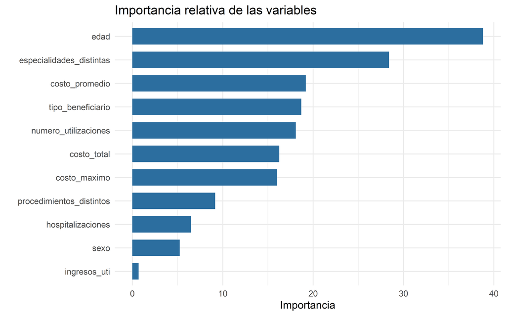

```r
ggplot(
  tabla_importancia,
  aes(
    x = reorder(
      Variable,
      Importancia
    ),
    y = Importancia
  )
) +
  geom_col(
    fill = "#2C6E9F",
    width = 0.7
  ) +
  coord_flip() +
  labs(
    title = "Importancia relativa de las variables",
    x = "",
    y = "Importancia"
  ) +
  theme_minimal(base_size = 12)
```

### 9.2.1 Interpretación

La importancia de las variables obtenida mediante el modelo Random Forest permite identificar cuáles predictores contribuyen en mayor medida a la clasificación de beneficiarios con TEA.

La **edad** fue la variable más influyente, con una importancia relativa de **38.82**, lo que sugiere que la distribución etaria constituye uno de los principales factores utilizados por el modelo para diferenciar beneficiarios con y sin TEA. Este resultado es consistente con la naturaleza del trastorno, cuyo diagnóstico y seguimiento presentan patrones característicos según la edad.

La segunda variable más importante fue el **número de especialidades distintas** (**28.40**), indicando que la diversidad de especialidades médicas consultadas aporta una cantidad considerable de información para la clasificación. Esto puede reflejar que los beneficiarios con TEA requieren una atención multidisciplinaria que involucra diferentes profesionales de la salud.

Posteriormente aparecen variables relacionadas con los **costos de atención**, como el costo promedio (**19.19**), el costo total (**16.26**) y el costo máximo (**16.03**), lo que evidencia que la intensidad del gasto en salud también constituye un elemento relevante para distinguir ambos grupos de beneficiarios.

Asimismo, variables asociadas a la utilización de los servicios de salud, como el **número de utilizaciones** (**18.09**) y el **número de procedimientos distintos** (**9.16**), presentan una importancia intermedia, indicando que la frecuencia y complejidad de la atención también contribuyen al proceso de clasificación.

En contraste, variables como el **sexo** (**5.24**) y especialmente los **ingresos a la UTI** (**0.69**) mostraron una influencia relativamente baja sobre el desempeño del modelo. Esto sugiere que, dentro de la información disponible, estos factores aportan poca capacidad discriminativa para identificar beneficiarios con TEA.

En conjunto, estos resultados muestran que la clasificación de beneficiarios con TEA depende principalmente de variables relacionadas con la edad, la complejidad de la atención recibida y los costos asociados al uso de los servicios de salud, más que de variables demográficas simples o de eventos clínicos poco frecuentes como el ingreso a unidades de cuidados intensivos.

# 10. Estimación del costo asociado al TEA

Los modelos predictivos permiten identificar beneficiarios con mayor probabilidad de presentar TEA; sin embargo, desde el punto de vista de la gestión en salud resulta igualmente importante comprender el impacto económico asociado a esta población. En esta sección se analiza el comportamiento del costo de atención según la presencia de TEA y diferentes características clínicas de los beneficiarios.

```r
base_costos <- base_beneficiarios %>%
  filter(costo_total > 0)
```

```r
nrow(base_beneficiarios)
```

```
## [1] 653630
```

```r
nrow(base_costos)
```

```
## [1] 652949
```

```r
sum(base_beneficiarios$costo_total <= 0)
```

```
## [1] 681
```

## 10.1 Distribución general del costo

```r
summary(
  base_costos$costo_total
)
```

```
##      Min.   1st Qu.    Median      Mean   3rd Qu.      Max.
## 1.000e-02 1.387e+02 3.300e+02 1.529e+03 7.984e+02 1.906e+06
```

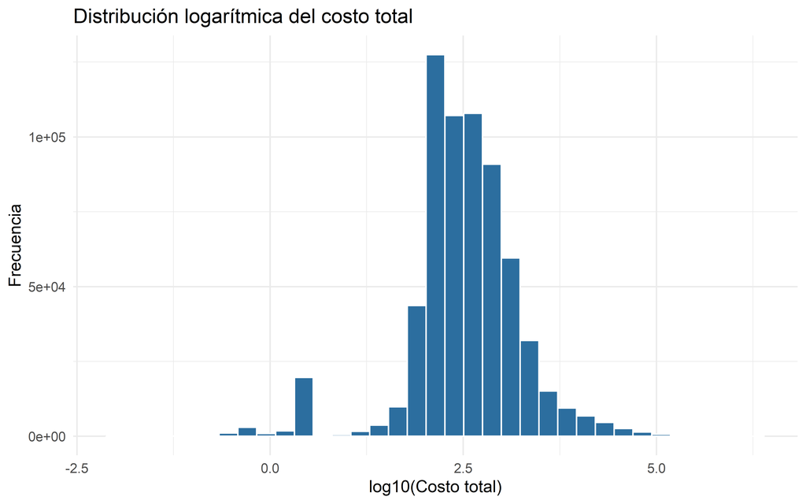

```r
ggplot(
  base_costos,
  aes(
    x = log10(costo_total)
  )
) +
geom_histogram(
  bins = 35,
  fill = "#2C6E9F",
  color = "white"
) +
labs(
  title = "Distribución logarítmica del costo total",
  x = "log10(Costo total)",
  y = "Frecuencia"
) +
theme_minimal(base_size = 12)
```

### 10.1.1 Interpretación

La distribución del costo total presenta una marcada asimetría positiva, caracterizada por un gran número de beneficiarios con costos bajos y un grupo reducido de individuos con costos considerablemente superiores. Debido a esta fuerte asimetría, la representación en escala logarítmica facilita la visualización de la distribución central de los datos y reduce el efecto de los valores extremos.

## 10.2 Costo según presencia de TEA

```r
costo_tea <- base_costos %>%
group_by(TEA) %>%
summarise(
Beneficiarios=n(),
Media=round(mean(costo_total),2),
Mediana=round(median(costo_total),2),
Desviacion=round(sd(costo_total),2),
Minimo=round(min(costo_total),2),
Maximo=round(max(costo_total),2),
.groups="drop"
)

knitr::kable(
costo_tea,
caption="Costo total según presencia de TEA."
)
```

Costo total según presencia de TEA.

| TEA | Beneficiarios | Media | Mediana | Desviacion | Minimo | Maximo |
| --- | --- | --- | --- | --- | --- | --- |
| 0 | 652138 | 1527.17 | 329.50 | 9753.55 | 0.01 | 1905829.57 |
| 1 | 811 | 3201.56 | 1803.21 | 4271.07 | 70.00 | 41100.15 |

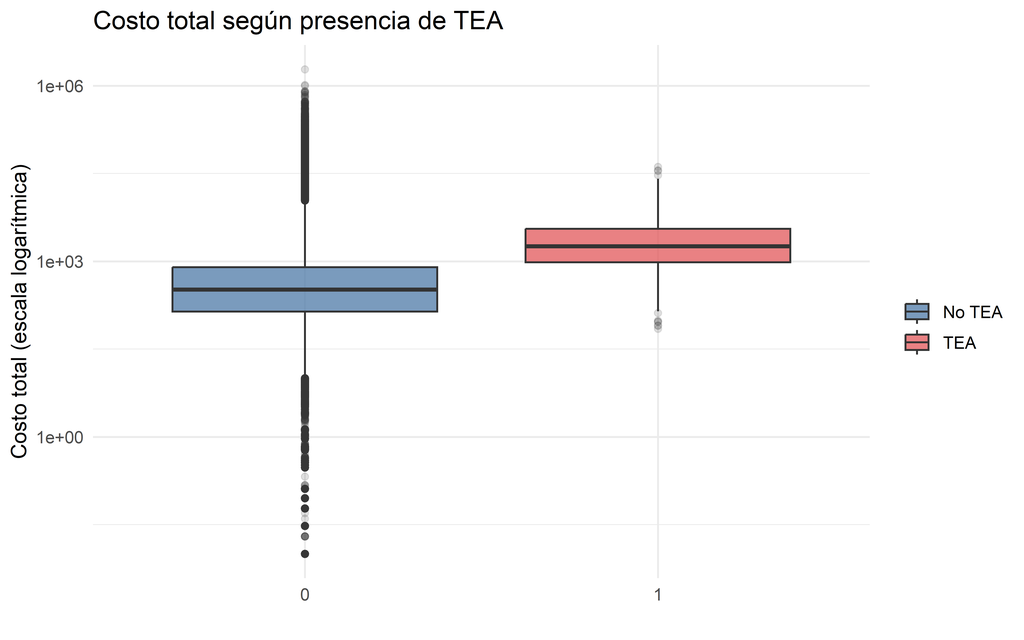

```r
ggplot(
base_costos,
aes(
factor(TEA),
costo_total,
fill=factor(TEA)
)
)+
geom_boxplot(
alpha=.75,
outlier.alpha=.15
)+
scale_y_log10()+
scale_fill_manual(
values=c("#4E79A7","#E15759"),
labels=c("No TEA","TEA")
)+
labs(
title="Costo total según presencia de TEA",
x="",
y="Costo total (escala logarítmica)",
fill=""
)+
theme_minimal(base_size=12)
```

**Interpretación**

La comparación del costo total entre beneficiarios con y sin TEA evidencia diferencias importantes en el gasto asociado a la atención en salud.

Los beneficiarios con **TEA** presentan un costo promedio de **3,201.56**, más del doble del observado en los beneficiarios **sin TEA** (**1,527.17**). Esta diferencia sugiere una mayor utilización de recursos sanitarios por parte de esta población.

La mediana también refleja este comportamiento, alcanzando **1,803.21** para los beneficiarios con TEA frente a **329.50** en aquellos sin la condición. Esto indica que la diferencia en costos no se debe únicamente a unos pocos casos extremos, sino que corresponde a un patrón general de mayor gasto dentro del grupo con TEA.

Adicionalmente, ambos grupos presentan una alta dispersión en los costos, especialmente los beneficiarios sin TEA, quienes alcanzan un costo máximo cercano a **1.9 millones**. Este resultado confirma la presencia de valores extremos previamente identificados durante el análisis exploratorio y justifica el uso de escalas logarítmicas para la representación gráfica de esta variable.

En conjunto, estos resultados muestran que la presencia de TEA se asocia con un mayor costo de atención médica, probablemente como consecuencia de una mayor frecuencia de utilización de los servicios de salud y de la necesidad de una atención más especializada y continua.

## 10.3 Relación entre edad y costo

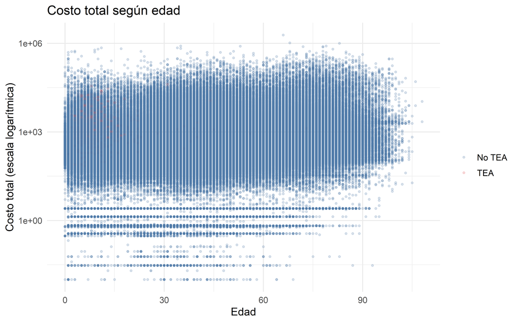

```r
ggplot(
base_costos,
aes(
edad,
costo_total,
color=factor(TEA)
)
)+
geom_point(
alpha=.20,
size=.8
)+
scale_y_log10()+
scale_color_manual(
values=c("#4E79A7","#E15759"),
labels=c("No TEA","TEA")
)+
labs(
title="Costo total según edad",
x="Edad",
y="Costo total (escala logarítmica)",
color=""
)+
theme_minimal(base_size=12)
```

**Interpretación**

La relación entre la edad y el costo total evidencia una alta variabilidad del gasto en prácticamente todos los grupos etarios. Aunque existen beneficiarios con costos bajos y altos a cualquier edad, se observa una mayor concentración de costos elevados durante la edad adulta y en adultos mayores, donde también se presentan los valores máximos de la distribución.

La utilización de una escala logarítmica permite visualizar simultáneamente beneficiarios con costos muy bajos y aquellos con gastos excepcionalmente altos, evidenciando la marcada asimetría de esta variable.

Los beneficiarios con TEA (puntos rojos) representan una proporción muy pequeña del total de la población analizada, por lo que visualmente quedan parcialmente ocultos por los beneficiarios sin TEA. No obstante, su distribución indica que los casos de TEA se concentran principalmente en edades tempranas y medias, coherente con la historia natural del trastorno y con los patrones observados en el análisis descriptivo.

En conjunto, la figura sugiere que la edad constituye un factor asociado al comportamiento del costo de atención y respalda los resultados obtenidos mediante Random Forest, donde la edad fue identificada como la variable de mayor importancia para la clasificación de beneficiarios con TEA.

## 10.4 Hospitalizaciones y costo

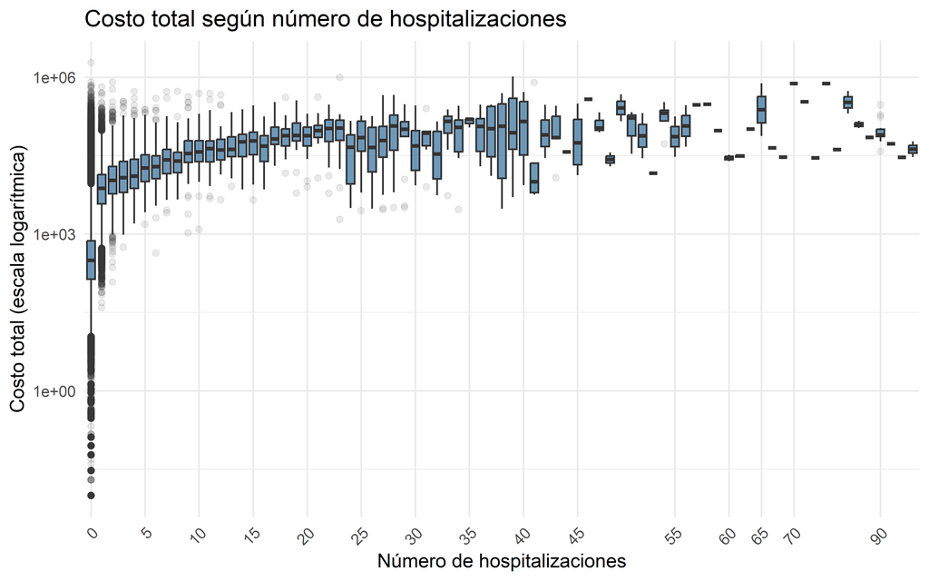

```r
ggplot(
  base_costos,
  aes(
    factor(hospitalizaciones),
    costo_total
  )
)+
geom_boxplot(
  fill="#2C6E9F",
  alpha=.70,
  outlier.alpha=.10
)+
scale_y_log10()+
scale_x_discrete(
  breaks = seq(0,90,5)
)+
labs(
  title="Costo total según número de hospitalizaciones",
  x="Número de hospitalizaciones",
  y="Costo total (escala logarítmica)"
)+
theme_minimal(base_size=12)+
theme(
  axis.text.x = element_text(angle = 45, hjust = 1)
)
```

**Interpretación**

La relación entre el número de hospitalizaciones y el costo total muestra una tendencia claramente creciente. En general, a medida que aumenta el número de hospitalizaciones, también se incrementa el costo de atención de los beneficiarios.

Los pacientes sin hospitalizaciones presentan la mayor variabilidad en los costos, ya que este grupo concentra la mayor parte de la población estudiada e incluye tanto beneficiarios con gastos mínimos como algunos casos de costos excepcionalmente elevados.

A partir de una hospitalización, la mediana del costo aumenta de forma progresiva y los cuartiles superiores se desplazan hacia valores cada vez mayores, indicando que la hospitalización constituye uno de los principales determinantes del gasto sanitario.

Aunque para números elevados de hospitalizaciones se observa una mayor dispersión, esta variabilidad se explica principalmente por el reducido número de beneficiarios en esos grupos. No obstante, la tendencia general permanece consistente: un mayor número de hospitalizaciones se asocia con mayores costos de atención.

Estos resultados son coherentes con los obtenidos durante el análisis de importancia de variables mediante Random Forest, donde las hospitalizaciones también contribuyeron a la clasificación de los beneficiarios, aunque con una importancia menor que variables como la edad o el número de especialidades atendidas.

## 10.5 Ingresos a UTI y costo

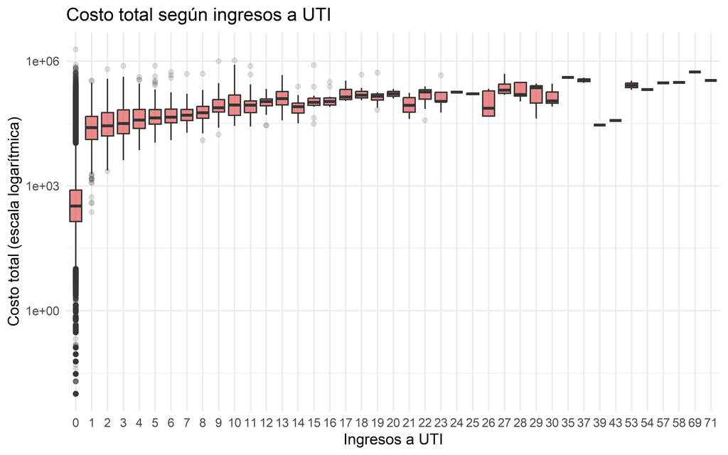

```r
ggplot(
base_costos,
aes(
factor(ingresos_uti),
costo_total
)
)+
geom_boxplot(
fill="#E15759",
alpha=.70,
outlier.alpha=.15
)+
scale_y_log10()+
labs(
title="Costo total según ingresos a UTI",
x="Ingresos a UTI",
y="Costo total (escala logarítmica)"
)+
theme_minimal(base_size=12)
```

**Interpretación**

La relación entre el número de ingresos a la Unidad de Cuidados Intensivos (UTI) y el costo total muestra un comportamiento claramente creciente. Los beneficiarios sin ingresos a UTI presentan, en promedio, los menores costos de atención, mientras que aquellos con uno o más ingresos exhiben un incremento progresivo en el gasto sanitario.

A medida que aumenta el número de ingresos a UTI, la mediana y el rango intercuartílico del costo total se desplazan hacia valores más elevados, reflejando el mayor consumo de recursos asociado a la atención de pacientes con mayor gravedad clínica.

En los niveles más altos de ingresos a UTI se observa una mayor variabilidad en los costos, atribuible principalmente al reducido número de beneficiarios que pertenecen a estos grupos. Sin embargo, la tendencia general permanece consistente y evidencia que los ingresos a cuidados intensivos constituyen uno de los principales determinantes del costo de la atención médica.

Estos resultados complementan los hallazgos obtenidos en las secciones anteriores, donde se observó que los beneficiarios con TEA presentan mayores costos promedio y un uso más intensivo de los servicios de salud. Aunque la variable *ingresos a UTI* mostró una baja importancia en el modelo Random Forest para discriminar la presencia de TEA, sí representa un factor altamente asociado al incremento del costo cuando estos eventos ocurren.

## 10.6 Modelo de costo esperado según perfil del beneficiario

Las secciones anteriores compararon el costo total mediante estadísticas descriptivas para una variable a la vez (TEA, edad, hospitalizaciones, ingresos a UTI). Sin embargo, en la práctica interesa estimar el costo esperado de un beneficiario considerando **varias características simultáneamente**. Para ello se ajusta un modelo lineal generalizado (GLM) con distribución Gamma y función de enlace logarítmica, una estrategia habitual en econometría de la salud para variables de costo estrictamente positivas y con fuerte asimetría a la derecha, como la observada en `costo_total` (sección 10.1).

```r
modelo_costo <- glm(
  costo_total ~ TEA + edad + hospitalizaciones + ingresos_uti + especialidades_distintas + sexo,
  data = base_costos,
  family = Gamma(link = "log")
)

summary(modelo_costo)
```

```
##
## Call:
## glm(formula = costo_total ~ TEA + edad + hospitalizaciones +
##     ingresos_uti + especialidades_distintas + sexo, family = Gamma(link = "log"),
##     data = base_costos)
##
## Coefficients:
##                            Estimate Std. Error t value Pr(>|t|)
## (Intercept)               6.1312937  0.0187767 326.538  < 2e-16 ***
## TEA                       1.5980998  0.2033883   7.857 3.93e-15 ***
## edad                      0.0155631  0.0003264  47.675  < 2e-16 ***
## hospitalizaciones         1.0051273  0.0079180 126.941  < 2e-16 ***
## ingresos_uti              0.4204551  0.0205350  20.475  < 2e-16 ***
## especialidades_distintas  0.1181465  0.0072251  16.352  < 2e-16 ***
## sexoM                     0.0991344  0.0149122   6.648 2.98e-11 ***
## sexoNão Informado        -0.1311573  0.0349825  -3.749 0.000177 ***
## ---
## Signif. codes:  0 '***' 0.001 '**' 0.01 '*' 0.05 '.' 0.1 ' ' 1
##
## (Dispersion parameter for Gamma family taken to be 33.33444)
##
##     Null deviance: 2009719  on 649480  degrees of freedom
## Residual deviance: 1590330  on 649473  degrees of freedom
##   (3468 observations deleted due to missingness)
## AIC: 10177281
##
## Number of Fisher Scoring iterations: 25
```

Debido a que el modelo utiliza un enlace logarítmico, los coeficientes se interpretan de forma multiplicativa una vez exponenciados: cada valor de `Factor_multiplicativo` indica por cuánto se multiplica el costo esperado ante un incremento de una unidad en la variable correspondiente (o, en el caso de `TEA`, al pasar de 0 a 1), manteniendo las demás variables constantes.

```r
tabla_coef_costo <- tibble(
  Variable = names(coef(modelo_costo)),
  Coeficiente = coef(modelo_costo),
  Factor_multiplicativo = exp(coef(modelo_costo))
)

knitr::kable(
  tabla_coef_costo,
  digits = 4,
  caption = "Coeficientes del modelo Gamma (enlace logarítmico) para el costo total."
)
```

Coeficientes del modelo Gamma (enlace logarítmico) para el costo total.

| Variable | Coeficiente | Factor_multiplicativo |
| --- | --- | --- |
| (Intercept) | 6.1313 | 460.0309 |
| TEA | 1.5981 | 4.9436 |
| edad | 0.0156 | 1.0157 |
| hospitalizaciones | 1.0051 | 2.7323 |
| ingresos_uti | 0.4205 | 1.5227 |
| especialidades_distintas | 0.1181 | 1.1254 |
| sexoM | 0.0991 | 1.1042 |
| sexoNão Informado | -0.1312 | 0.8771 |

**Interpretación**

Los resultados confirman las expectativas planteadas: el factor multiplicativo de `TEA` es **4,94** (coeficiente = 1,5981), la asociación más fuerte de todo el modelo. Esto indica que, manteniendo constantes la edad, las hospitalizaciones, los ingresos a UTI, el número de especialidades distintas y el sexo, el costo esperado de un beneficiario con TEA es prácticamente **5 veces** el de un beneficiario sin TEA. Este efecto ajustado es incluso mayor que la diferencia bruta observada en la sección 10.2 (costo promedio de 3.201,56 frente a 1.527,17, una razón de ~2,1x). Esto es consistente con que los beneficiarios con TEA son, en promedio, mucho más jóvenes (9,16 años frente a 38,77 años, sección 5.5.1): como la edad se asocia con un mayor costo (factor = 1,0157 por año), la corta edad de los beneficiarios con TEA empuja su costo hacia abajo, por lo que, al controlar por edad, el efecto propio del TEA sobre el costo resulta aún más marcado que la simple comparación de promedios.

Las hospitalizaciones presentan el segundo efecto más fuerte (factor = **2,73**): cada hospitalización adicional multiplica el costo esperado por 2,73, un efecto incluso mayor que el de los ingresos a UTI (factor = **1,52**). Le siguen el número de especialidades distintas (factor = **1,13** por especialidad adicional) y el sexo, donde los beneficiarios masculinos presentan un costo esperado 10,4% mayor que las beneficiarias femeninas (factor = 1,10), mientras que los beneficiarios con sexo “Não Informado” presentan un costo esperado 12,3% menor que la referencia (factor = 0,88); esta última asociación no tiene una interpretación clínica directa y probablemente refleja un patrón de registro administrativo incompleto más que un efecto real del sexo sobre el costo.

**Costo esperado bajo distintos perfiles**

A modo de ilustración, se utiliza el modelo ajustado para estimar el costo esperado bajo algunos perfiles representativos de beneficiarios, combinando simultáneamente la presencia de TEA, la edad y la ocurrencia de hospitalización o ingreso a UTI.

```r
perfiles <- tibble(
  Perfil = c(
    "Adulto, sin TEA, sin hospitalización/UTI",
    "Adulto, con TEA, sin hospitalización/UTI",
    "Niño, sin TEA, sin hospitalización/UTI",
    "Niño, con TEA, sin hospitalización/UTI",
    "Niño, con TEA, con hospitalización y UTI"
  ),
  TEA = c(0, 1, 0, 1, 1),
  edad = c(40, 40, 8, 8, 8),
  hospitalizaciones = c(0, 0, 0, 0, 1),
  ingresos_uti = c(0, 0, 0, 0, 1),
  especialidades_distintas = c(1, 1, 1, 1, 2),
  sexo = c("M", "M", "M", "M", "M")
)

perfiles <- perfiles %>%
  mutate(
    costo_esperado = predict(
      modelo_costo,
      newdata = perfiles,
      type = "response"
    )
  )

knitr::kable(
  perfiles,
  digits = 0,
  caption = "Costo total esperado según el modelo Gamma, para distintos perfiles de beneficiario."
)
```

Costo total esperado según el modelo Gamma, para distintos perfiles de beneficiario.

| Perfil | TEA | edad | hospitalizaciones | ingresos_uti | especialidades_distintas | sexo | costo_esperado |
| --- | --- | --- | --- | --- | --- | --- | --- |
| Adulto, sin TEA, sin hospitalización/UTI | 0 | 40 | 0 | 0 | 1 | M | 1065 |
| Adulto, con TEA, sin hospitalización/UTI | 1 | 40 | 0 | 0 | 1 | M | 5267 |
| Niño, sin TEA, sin hospitalización/UTI | 0 | 8 | 0 | 0 | 1 | M | 647 |
| Niño, con TEA, sin hospitalización/UTI | 1 | 8 | 0 | 0 | 1 | M | 3201 |
| Niño, con TEA, con hospitalización y UTI | 1 | 8 | 1 | 1 | 2 | M | 14987 |

**Interpretación**

La tabla confirma que el perfil de mayor costo esperado corresponde al niño con TEA, hospitalización e ingreso a UTI (**$14.987**), aproximadamente 14 veces el costo esperado de un adulto sin TEA y sin hospitalización ni UTI (**$1.065**). Sin embargo, y contrario a lo anticipado, el perfil de **menor** costo esperado no es el adulto sin TEA, sino el **niño sin TEA** (**$647**): dado que la edad tiene un efecto positivo sobre el costo (factor = 1,0157 por año), un beneficiario más joven presenta, en igualdad de las demás condiciones, un costo esperado menor que uno de mayor edad. Este resultado ilustra precisamente la utilidad de un modelo multivariado frente a comparaciones univariadas: el efecto de la edad y el efecto del TEA operan en direcciones que no siempre coinciden con la intuición inicial.

Vale la pena notar que el costo esperado para el perfil “Niño, con TEA, sin hospitalización/UTI” (**$3.201**) coincide casi exactamente con el costo promedio observado para el conjunto de beneficiarios con TEA en la sección 10.2 ($3.201,56), lo cual ofrece una validación razonable de que el modelo reproduce el comportamiento agregado ya documentado descriptivamente, para el perfil que mejor representa al beneficiario “típico” con TEA de la base (edad media ≈ 9 años).

Como ya se señaló, esta estimación es asociativa y comparte la limitación discutida en la sección 11.1 respecto a `especialidades_distintas` y otras variables de utilización, que reflejan en parte la atención recibida después del diagnóstico. A esto se suma el hallazgo de la sección 5.3.2: dado que `DESC_ESPECIALIDADE` presentó un 99,88% de valores faltantes específicamente entre las utilizaciones con TEA, la variable `especialidades_distintas` incluida en este modelo de costo debe interpretarse con la misma cautela señalada allí.

# 11. Conclusiones

El presente trabajo permitió construir una base de datos a nivel de beneficiario a partir de los registros individuales de utilización de los servicios de salud, integrando información demográfica, variables de utilización, procedimientos, especialidades médicas y costos asociados. Esta etapa de preparación de datos constituyó un paso fundamental para el desarrollo de los modelos de minería de datos posteriores.

El análisis descriptivo mostró diferencias importantes entre los beneficiarios con y sin TEA. En particular, los beneficiarios con TEA presentaron un mayor número de utilizaciones de los servicios de salud, una mayor cantidad de procedimientos realizados y costos promedio superiores al resto de la población. Estos resultados evidencian un patrón de atención más intensivo y una mayor demanda de recursos sanitarios.

En cuanto al aprendizaje supervisado, se implementaron cinco algoritmos de clasificación: Árbol de Decisión, Random Forest, XGBoost, Support Vector Machine y K-Nearest Neighbors. Todos los modelos alcanzaron valores elevados de ROC-AUC, reflejando una buena capacidad de discriminación entre beneficiarios con y sin TEA. Sin embargo, debido al fuerte desbalance de clases presente en la base de datos, la sensibilidad y el PR-AUC permitieron realizar una evaluación más apropiada del desempeño sobre la clase minoritaria.

Entre los modelos evaluados, **Random Forest** presentó el mejor equilibrio entre capacidad discriminativa, precisión y desempeño sobre la clase minoritaria, mientras que **XGBoost** obtuvo el mayor valor de ROC-AUC. Por su parte, **KNN** logró la mayor sensibilidad, aunque con una disminución importante en la precisión. Estos resultados muestran que la selección del modelo depende del objetivo del análisis y del balance deseado entre detección de casos positivos y reducción de falsos positivos.

El análisis de importancia de variables evidenció que la **edad**, el **número de especialidades médicas consultadas**, el **costo promedio** y el **número de utilizaciones** fueron los predictores con mayor influencia sobre la clasificación de los beneficiarios. Estos resultados son consistentes con el análisis exploratorio realizado previamente y confirman que las diferencias observadas inicialmente también son identificadas por los modelos predictivos.

Desde el enfoque de aprendizaje no supervisado, el algoritmo **K-means** permitió identificar dos perfiles claramente diferenciados de beneficiarios, mientras que **Isolation Forest** detectó un pequeño grupo de pacientes con patrones de utilización significativamente diferentes al resto de la población. Ambos métodos coincidieron en señalar que existe un subconjunto reducido de beneficiarios caracterizado por un uso mucho más intensivo de los servicios de salud.

Finalmente, el análisis económico mostró que los beneficiarios con TEA presentan costos promedio considerablemente superiores a los observados en la población sin TEA. Asimismo, variables como el número de hospitalizaciones y los ingresos a unidades de cuidados intensivos se asociaron con incrementos progresivos del costo total, evidenciando la estrecha relación entre la complejidad clínica y el gasto sanitario.

En conjunto, los resultados obtenidos demuestran que las técnicas de minería de datos constituyen herramientas útiles para caracterizar beneficiarios, identificar perfiles de riesgo, detectar patrones atípicos y apoyar la toma de decisiones orientadas a la gestión eficiente de los recursos en salud.

## 11.1 Limitaciones

El presente estudio presenta algunas limitaciones que deben considerarse al interpretar los resultados. En primer lugar, la base de datos presentó un fuerte desbalance entre beneficiarios con y sin TEA, situación que dificulta la identificación de la clase minoritaria y exige el uso de métricas de evaluación distintas a la exactitud.

Adicionalmente, la información disponible corresponde únicamente a variables administrativas y de utilización de servicios de salud, por lo que no fue posible incorporar información clínica más detallada, antecedentes médicos o variables socioeconómicas que podrían mejorar el desempeño de los modelos predictivos.

Una limitación adicional, relacionada con la interpretación del modelo, es que algunas de las variables predictoras más importantes —en particular el número de especialidades consultadas y los costos acumulados— reflejan en parte la atención multidisciplinaria y el seguimiento que reciben los beneficiarios *después* de haber sido diagnosticados con TEA (terapias de rehabilitación, controles periódicos, etc.). En consecuencia, parte de la capacidad predictiva de los modelos podría explicarse por el patrón de atención asociado al diagnóstico ya establecido, más que por factores de riesgo previos e independientes de él. Esto no invalida los modelos como herramienta descriptiva o de priorización dentro de la población ya atendida, pero sí limita su interpretación como predictores puramente prospectivos del riesgo de TEA.

Finalmente, los resultados obtenidos corresponden a una única base de datos y, por tanto, la capacidad de generalización de los modelos debería evaluarse utilizando información proveniente de otras poblaciones o periodos de observación.

## 11.2 Trabajos futuros

Como trabajo futuro se propone evaluar técnicas adicionales de balanceo de clases, como SMOTE o ADASYN, con el fin de mejorar la sensibilidad de los modelos supervisados sobre la población con TEA.

Asimismo, sería interesante incorporar variables clínicas complementarias y explorar modelos más avanzados de aprendizaje automático, incluyendo redes neuronales profundas o métodos de ensamblado adicionales.

Finalmente, la sección 10.6 presentó un primer modelo de costo esperado (GLM Gamma) que combina simultáneamente TEA, edad, hospitalizaciones e ingresos a UTI. Como trabajo futuro, este modelo podría extenderse incorporando variables clínicas y administrativas adicionales, evaluando formalmente su bondad de ajuste (por ejemplo, mediante validación cruzada del error de predicción) y comparándolo con modelos alternativos (por ejemplo, regresión log-lineal o modelos de dos partes para los costos iguales a cero), con el fin de apoyar estrategias de planificación y asignación eficiente de recursos dentro del sistema de salud.